# Compare Co-expression To PPI

Joaquim Aguirre-Plans

2022-11-23

```r
packrat::init("/home/j.aguirreplans/Projects/Scipher/SampleSize/scripts/SampleSizeR")
```

```
## Initializing packrat project in directory:
## - "~/Projects/Scipher/SampleSize/scripts/SampleSizeR"
```

```
## Initialization complete!
```

```r
library(data.table)
library(dplyr)
library(FSA)
```

```r
library(ggplot2)
library(igraph)
require(magrittr)
library(patchwork)
library(pROC)
library(ROCR)
library(tidyr)
library(wTO)
set.seed(1510)
options(bitmapType='cairo')
`%ni%` <- Negate(`%in%`)
```

Select parameters of the analysis:

```r
dataset = "gtex"
type_dataset = "Whole.Blood"
sample_group_type = "tumor" # if dataset = "tcga"
type_counts = "reads" # tpm, reads
sizes_selected = c(20, 100, 200, 300)
threshold_selected = 0.05
```

### Read PPI-related files and calculate distance matrices between protein pairs

Define a function to calculate the distance matrix in a network:

```r
#'  calculate_distance_matrix_ppi
#'  Function to calculate distances between pairs of nodes of the PPI network.
#'  @param ppi_net PPI network in igraph format.
#'
calculate_distance_matrix_ppi = function(ppi_net){
  # Calculate distances
  ppi_distances = distances(ppi_net)
  # Order the nodes
  ppi_distances = ppi_distances[order(rownames(ppi_distances)), order(colnames(ppi_distances))]
  # Convert the matrix to an in-line format
  ppi_distances = ppi_distances %>% wTO.in.line() %>% rename(distances=wTO)
  # Remove infinite distances (from different components)
  ppi_distances = ppi_distances %>% filter(!(is.infinite(distances)))
  return(ppi_distances)
}
```

Calculate the distance matrices if necessary:

```r
# Calculate distances between pairs of nodes of the PPI and NCI networks
ppi_nci_distances_file = "/work/ccnr/j.aguirreplans/data/PPI/PPI_NCI_merged_distances.txt"
if (!(file.exists(ppi_nci_distances_file))){
  # Calculate PPI distances
  ppi_distances_file = "/work/ccnr/j.aguirreplans/data/PPI/PPI_2022_04042022_distances.txt"
  if (!(file.exists(ppi_distances_file))){
    # Read the PPI network
    ppi_file = "/work/ccnr/j.aguirreplans/data/PPI/PPI_2022_04042022.csv"
    ppi_df = fread(ppi_file) %>% dplyr::select(HGNC_Symbol.1, HGNC_Symbol.2) %>% filter(!(HGNC_Symbol.1 == HGNC_Symbol.2)) %>% unique()
    ppi_net = graph_from_data_frame(ppi_df, directed=F) %>% simplify()
    gsize(ppi_net)
    gorder(ppi_net)
    head(ppi_df)
    # Calculate distances of PPI
    ppi_distances = calculate_distance_matrix_ppi(ppi_net)
    # Save file
    ppi_distances %>% fwrite(ppi_distances_file)
  } else {
    # Read PPI distances
    ppi_distances = fread(ppi_distances_file)
  }
  # Calculate NCI distances
  nci_distances_file = "/work/ccnr/j.aguirreplans/data/PPI/ncPPI_PPI_2022_04042022_distances.txt"
  if (!(file.exists(nci_distances_file))){
    # Read NCI network
    nci_file = "/work/ccnr/j.aguirreplans/data/PPI/ncPPI_PPI_2022_04042022.csv"
    nci_df = fread(nci_file) %>% dplyr::select(HGNC_Symbol.1, HGNC_Symbol.2) %>% filter(!(HGNC_Symbol.1 == HGNC_Symbol.2)) %>% unique()
    nci_net = graph_from_data_frame(nci_df, directed=F) %>% simplify()
    gsize(nci_net)
    gorder(nci_net)
    head(nci_df)
    # Calculate distances of NCI
    nci_distances = calculate_distance_matrix_ppi(nci_net)
    # Save file
    nci_distances %>% fwrite(nci_distances_file)
  } else {
    # Read NCI distances
    nci_distances = fread(nci_distances_file)
  }
  # Merge PPI and NCI distances
  ppi_distances = ppi_distances %>% rename("distances_ppi"="distances")
  nci_distances = nci_distances %>% rename("distances_nci"="distances")
  ppi_nci_distances = ppi_distances %>% full_join(nci_distances, by=c("Node.1", "Node.2"))
  rm(ppi_distances)
  rm(nci_distances)
  ppi_nci_distances %>% fwrite(ppi_nci_distances_file)
} else {
  ppi_nci_distances = fread(ppi_nci_distances_file)
}
head(ppi_nci_distances)
```

```
##    Node.1 Node.2 distances_ppi distances_nci
## 1:   A1BG   A1CF             3             3
## 2:   A1BG    A2M             2             2
## 3:   A1CF    A2M             2             2
## 4:   A1BG  A2ML1             2             2
## 5:   A1CF  A2ML1             3             3
## 6:    A2M  A2ML1             2             2
```

The PPI has the following number of direct interactions:

```r
nrow(ppi_nci_distances %>% filter(distances_ppi == 1) %>% select(Node.1, Node.2))
```

```
## [1] 529506
```

The NCI has the following number of direct interactions:

```r
nrow(ppi_nci_distances %>% filter(distances_nci == 1) %>% select(Node.1, Node.2))
```

```
## [1] 1107232
```

Save the sorted PPI and NCI networks if necessary:

```r
ppi_sorted_file = "/work/ccnr/j.aguirreplans/data/PPI/PPI_2022_04042022_sorted.csv"
if (!(file.exists(ppi_sorted_file))){
  ppi_nci_distances %>% filter(distances_ppi == 1) %>% select(Node.1, Node.2) %>% fwrite(ppi_sorted_file)
}
nci_sorted_file = "/work/ccnr/j.aguirreplans/data/PPI/ncPPI_PPI_2022_04042022_sorted.csv"
if (!(file.exists(nci_sorted_file))){
  ppi_nci_distances %>% filter(distances_nci == 1) %>% select(Node.1, Node.2) %>% fwrite(nci_sorted_file)
}
```

The maximum distance in the PPI network is:

```r
max((ppi_nci_distances %>% filter(!(is.na(distances_ppi))))$distances_ppi)
```

```
## [1] 7
```

The maximum distance in the NCI network is:

```r
max(ppi_nci_distances$distances_nci)
```

```
## [1] 9
```

Plot the distribution of distances between proteins in the PPI network:

```r
ppi_distances_plot = ppi_nci_distances %>%
  filter(!(is.na(distances_ppi))) %>%
  ggplot(aes(x=distances_ppi)) +
  geom_histogram( binwidth=1, fill="#69b3a2", color="#e9ecef", alpha=0.9) +
  scale_y_continuous(trans = scales::log10_trans()) +
  theme_linedraw() +
  xlab("Distance in the PPI network") +
  ylab("Log(Count)") +
  theme(aspect.ratio=1,
        plot.title =  element_text(size = 15, face="bold"),
        axis.title = element_text(size = 14, face="bold"),
        axis.text = element_text(size = 13),
        panel.grid.major=element_blank(),
        panel.grid.minor = element_blank(),
        legend.text = element_text(size = 13),
        legend.title=element_text(size=14, face="bold"),
        text = element_text(family = "Helvetica"))
ppi_distances_plot_file = "/home/j.aguirreplans/Projects/Scipher/SampleSize/data/out/plots/ppi_distances.png"
ggsave(
  ppi_distances_plot_file,
  plot=ppi_distances_plot,
  dpi = 1200,
  units = c("px")
)
```

```
## Saving 8400 x 6000 px image
```

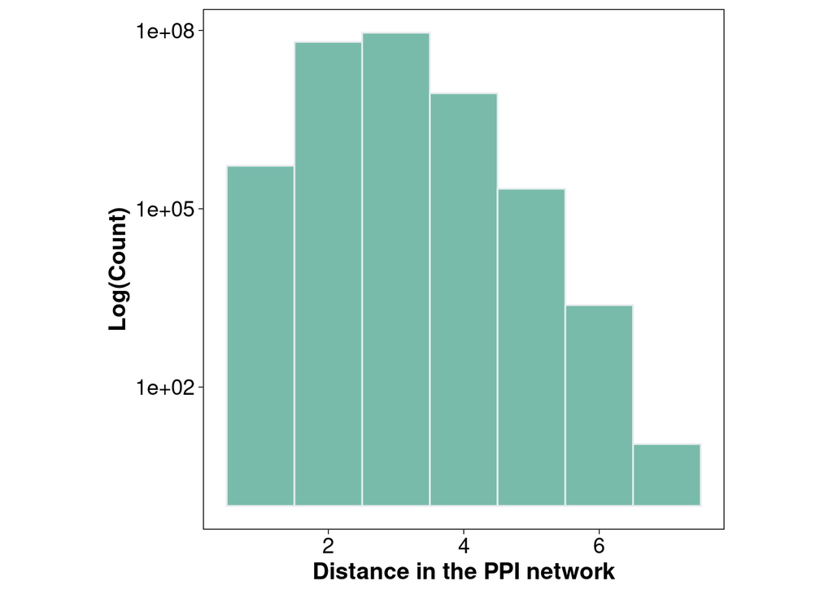

```r
print(ppi_distances_plot)
```

Plot the distribution of distances between genes/proteins in the NCI network:

```r
nci_distances_plot = ppi_nci_distances %>%
  ggplot(aes(x=distances_nci)) +
  geom_histogram( binwidth=1, fill="#69b3a2", color="#e9ecef", alpha=0.9) +
  scale_y_continuous(trans = scales::log10_trans()) +
  theme_linedraw() +
  xlab("Distance in the NCI network") +
  ylab("Log(Count)") +
  theme(aspect.ratio=1,
        plot.title =  element_text(size = 15, face="bold"),
        axis.title = element_text(size = 14, face="bold"),
        axis.text = element_text(size = 13),
        panel.grid.major=element_blank(),
        panel.grid.minor = element_blank(),
        legend.text = element_text(size = 13),
        legend.title=element_text(size=14, face="bold"),
        text = element_text(family = "Helvetica"))
nci_distances_plot_file = "/home/j.aguirreplans/Projects/Scipher/SampleSize/data/out/plots/nci_distances.png"
ggsave(
  nci_distances_plot_file,
  plot=nci_distances_plot,
  dpi = 1200,
  units = c("px")
)
```

```
## Saving 8400 x 6000 px image
```

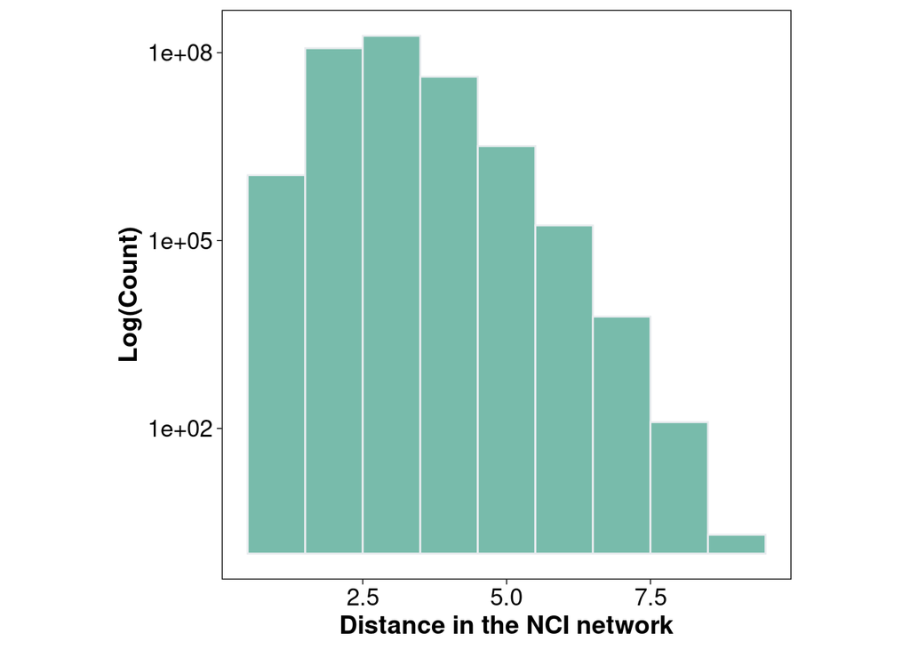

```r
print(nci_distances_plot)
```

### Define the protein pair sets to study

Read the list of genes in the co-expression networks that we are studying:

```r
if(dataset == "gtex"){
  coexpression_gene_info_file = sprintf("/work/ccnr/j.aguirreplans/Databases/GTEx/v8/%s/genes_from_rnaseq_filtered_files_by_tissue/gtex_rnaseq_gene_info_%s.csv", type_counts, type_dataset)
} else if(dataset == "tcga"){
  coexpression_gene_info_file = sprintf("/work/ccnr/j.aguirreplans/Databases/TCGA/2022-11-18-Dataset/TCGA/out/%s/%s/filter_genes_low_counts/genes_filtered_files_by_sample_group/rnaseq_gene_info_%s.csv", type_counts, sample_group_type, type_dataset)
} else if(dataset == "scipher"){
  coexpression_gene_info_file = sprintf("/home/j.aguirreplans/Projects/Scipher/SampleSize/data/Dec2021/00_data/genes_from_rnaseq_filtered_files_by_group/scipher_rnaseq_gene_info_%s.csv", type_dataset)
}

coexpression_gene_info_df = fread(coexpression_gene_info_file) %>% filter(enough_counts == TRUE)
length(unique(coexpression_gene_info_df$HGNC_Symbol))
```

```
## [1] 15148
```

Filter the matrix of distances between protein/gene pairs:

```r
ppi_nci_distances_filt = ppi_nci_distances %>% filter((Node.1 %in% unique(coexpression_gene_info_df$HGNC_Symbol)) & (Node.2 %in% unique(coexpression_gene_info_df$HGNC_Symbol)))
rm(ppi_nci_distances)
```

The maximum distance in the PPI network after filtering by genes that are in the gene expression dataset is:

```r
max((ppi_nci_distances_filt %>% filter(!(is.na(distances_ppi))))$distances_ppi)
```

```
## [1] 6
```

The maximum distance in the NCI network after filtering by genes that are in the gene expression dataset is:

```r
max(ppi_nci_distances_filt$distances_nci)
```

```
## [1] 7
```

Select the PPIs in the gene expression dataset:

```r
ppi_interactions = ppi_nci_distances_filt %>% filter(distances_ppi == 1) %>% select(Node.1, Node.2)
nrow(ppi_interactions)
```

```
## [1] 411028
```

Select the NCI in the gene expression dataset:

```r
nci_interactions = ppi_nci_distances_filt %>% filter(distances_nci == 1) %>% select(Node.1, Node.2)
nrow(nci_interactions)
```

```
## [1] 421789
```

Select random control interactions of the same size as the PPI:

```r
random_pp_pairs = ppi_nci_distances_filt %>%
  filter(!(is.na(distances_ppi))) %>% filter((!(distances_nci == 1)) & (!(distances_ppi == 1))) %>%
  #select(Node.1, Node.2) %>%
  slice_sample(n=dim(ppi_interactions)[1], replace = FALSE)
nrow(random_pp_pairs)
```

```
## [1] 411028
```

Select random control interactions of the same size as the PPI that are far in the PPI:

```r
max_ppi_filt_distance = max((ppi_nci_distances_filt %>% filter(!(is.na(distances_ppi))))$distances_ppi)
num_selected_interactions = dim(ppi_interactions)[1]
random_far_pp_pairs = ppi_nci_distances_filt[0,]
for (distance in (seq(max_ppi_filt_distance, 2))){
  random_far_pp_pairs = rbind(random_far_pp_pairs, ppi_nci_distances_filt %>%
    filter(!(is.na(distances_ppi))) %>%
    filter(distances_ppi == distance))
  if (dim(random_far_pp_pairs)[1] >= num_selected_interactions){
    break
  }
}
random_far_pp_pairs = random_far_pp_pairs %>%
  slice_sample(n=num_selected_interactions, replace = FALSE)
nrow(random_far_pp_pairs)
```

```
## [1] 411028
```

Select random control interactions of the same size as the NCI that are far in the NCI:

```r
max_nci_filt_distance = max((ppi_nci_distances_filt %>% filter(!(is.na(distances_nci))))$distances_nci)
num_selected_interactions = dim(nci_interactions)[1]
random_far_nc_pairs = ppi_nci_distances_filt[0,]
for (distance in (seq(max_nci_filt_distance, 2))){
  random_far_nc_pairs = rbind(random_far_nc_pairs, ppi_nci_distances_filt %>%
    filter(!(is.na(distances_nci))) %>%
    filter(distances_nci == distance))
  if (dim(random_far_nc_pairs)[1] >= num_selected_interactions){
    break
  }
}
random_far_nc_pairs = random_far_nc_pairs %>%
  slice_sample(n=num_selected_interactions, replace = FALSE)
nrow(random_far_nc_pairs)
```

```
## [1] 421789
```

Merge all the selected pairs in the same dataframe:

```r
pairs = (ppi_interactions %>% mutate(ppi=TRUE)) %>%
  full_join((nci_interactions %>% mutate(nci=TRUE)), by=c("Node.1", "Node.2")) %>%
  left_join(ppi_nci_distances_filt, by=c("Node.1", "Node.2")) %>%
  full_join((ppi_nci_distances_filt %>% filter((distances_ppi >= 5) | (distances_nci >= 5))), by=c("Node.1", "Node.2", "distances_ppi", "distances_nci")) %>%
  full_join((random_pp_pairs %>% mutate(random_not_ppi=TRUE)), by=c("Node.1", "Node.2", "distances_ppi", "distances_nci")) %>%
  full_join((random_far_pp_pairs %>% mutate(random_far_not_ppi=TRUE)), by=c("Node.1", "Node.2", "distances_ppi", "distances_nci")) %>%
  full_join((random_far_nc_pairs %>% mutate(random_far_not_nci=TRUE)), by=c("Node.1", "Node.2", "distances_ppi", "distances_nci")) %>%
  replace_na(list(ppi=FALSE, nci=FALSE, random_not_ppi=FALSE, random_far_not_ppi=FALSE, random_far_not_nci=FALSE))
head(pairs)
```

```
##    Node.1 Node.2  ppi  nci distances_ppi distances_nci random_not_ppi
## 1: ABCA10  ABCA6 TRUE TRUE             1             1          FALSE
## 2:  ABCA2  ABCA6 TRUE TRUE             1             1          FALSE
## 3:  ABCA6  ABCA8 TRUE TRUE             1             1          FALSE
## 4: ABCA10  ABCA9 TRUE TRUE             1             1          FALSE
## 5:   A1BG  ABCC6 TRUE TRUE             1             1          FALSE
## 6:  ABCD1  ABCD2 TRUE TRUE             1             1          FALSE
##    random_far_not_ppi random_far_not_nci
## 1:              FALSE              FALSE
## 2:              FALSE              FALSE
## 3:              FALSE              FALSE
## 4:              FALSE              FALSE
## 5:              FALSE              FALSE
## 6:              FALSE              FALSE
```

```r
pairs_file = "/home/j.aguirreplans/Projects/Scipher/SampleSize/data/out/tables/ppi_analysis_pairs.txt"
pairs %>% fwrite(pairs_file)
pairs = fread(pairs_file)
```

### Read the co-expression networks across different sample sizes and extract the co-expression of the protein pair sets

Fetch the files containing the gene co-expression networks of different sample sizes:

```r
coexpression_dir = sprintf("/scratch/j.aguirreplans/Scipher/SampleSizeProject/networks_%s/reads/%s/consensus", dataset, type_dataset)
all_coexpression_files = list.files(coexpression_dir)
coexpression_files_selected = data.frame(matrix(ncol=length(c("size", "file")),nrow=0, dimnames=list(NULL, c("size", "file"))))

for (coexpression_file in all_coexpression_files){
  file_split = strsplit(gsub(".net", "", coexpression_file), split="_")[[1]]
  size = as.numeric(file_split[(length(file_split)-1)])
  if (size %in% sizes_selected){
    coexpression_files_selected = rbind(coexpression_files_selected, data.frame(size=size, file=paste(coexpression_dir, coexpression_file, sep="/")))
  }
}
```

```r
coexpression_pairs_file = sprintf("/home/j.aguirreplans/Projects/Scipher/SampleSize/data/out/tables/ppi_analysis_pairs_pval_%s_%s_%s.txt", as.character(threshold_selected), dataset, type_dataset)
if (!(file.exists(coexpression_pairs_file))){
  coexpression_pairs_filt = data.frame(pairs)
  for (size_selected in sort(coexpression_files_selected$size)){
    coexpression_file = (coexpression_files_selected %>% filter(size == size_selected))$file
    coexpression_df = fread(coexpression_file)
    # Turn unsignificant co-expression values to 0
    coexpression_df$CN = ifelse(coexpression_df$pval.fisher >= threshold_selected, 0, coexpression_df$CN)
    # Rename CN column into size selected
    coexpression_df = coexpression_df %>%
      select(-pval.fisher) %>%
      rename(!!as.character(size_selected) := "CN")
    # Merge current co-expression with other co-expression sizes
    coexpression_pairs_filt = coexpression_pairs_filt %>% left_join(coexpression_df, by=c("Node.1", "Node.2"))
    rm(coexpression_df)
  }
  coexpression_pairs_filt %>% fwrite(coexpression_pairs_file)
} else {
  coexpression_pairs_filt = fread(coexpression_pairs_file)
}
```

Do the same, but this time without setting to 0 the statistically insignificant co-expression values:

```r
coexpression_pairs_file = sprintf("/home/j.aguirreplans/Projects/Scipher/SampleSize/data/out/tables/ppi_analysis_pairs_%s_%s.txt", dataset, type_dataset)
if (!(file.exists(coexpression_pairs_file))){
  coexpression_pairs = data.frame(pairs)
  for (size_selected in sort(coexpression_files_selected$size)){
    coexpression_file = (coexpression_files_selected %>% filter(size == size_selected))$file
    coexpression_df = fread(coexpression_file) %>%
      select(-pval.fisher) %>%
      rename(!!as.character(size_selected) := "CN")
    # Merge current co-expression with other co-expression sizes
    coexpression_pairs = coexpression_pairs %>% left_join(coexpression_df, by=c("Node.1", "Node.2"))
    rm(coexpression_df)
  }
  coexpression_pairs %>% fwrite(coexpression_pairs_file)
} else {
  coexpression_pairs = fread(coexpression_pairs_file)
}
```

### Plot gene co-expression vs. sample size

```r
colors_defined = c("PPI" = "#DBA9CA",
                   "PPI & iNCI" = "#FAF69E",
                   "Random" = "#B8BECC",
                   "Random pairs in PPI" = "#B8BECC",
                   "Random (distance > 4)" = "#543F4D",
                   "Distance > 4" = "#543F4D",
                   "Random pairs in PPI (dist. > 4)" = "#543F4D",
                   "Random pairs in PPI & iNCI (dist. > 4)" = "#545334",
                   "1" = "#DBA9CA",
                   "2" = "#a8829b",
                   "3" = "#87677c",
                   "4" = "#5e4857",
                   "5" = "#40303b",
                   "6" = "#1c151a")
```

Plot the co-expression of pairs of proteins grouped by their distance in the PPI network:

Boxplot plotting the zeroes:

```r
boxplot_ppi_coexpression_by_distances_file = sprintf("/home/j.aguirreplans/Projects/Scipher/SampleSize/data/out/plots/ppi_coexpression_boxplot_by_ppi_distance_pval_%s_%s_%s.png", as.character(threshold_selected), dataset, type_dataset)
colors_defined_filt = colors_defined[names(colors_defined) %in% c("1", "2", "3", "4", "5", "6")]
boxplot_ppi_coexpression_by_distances = coexpression_pairs_filt %>%
  select(-ppi, -nci, -distances_nci, -random_not_ppi, -random_far_not_ppi, -random_far_not_nci) %>%
  filter(!(is.na(distances_ppi))) %>%
  pivot_longer(as.character(sizes_selected), names_to = "size", values_to = "correlation", names_transform = list(size = as.character), values_transform = list(correlation = as.numeric)) %>%
  filter(!(is.na(correlation))) %>%
  mutate(across(c(distances_ppi), as.character)) %>%
  ggplot() +
  aes(x = reorder(size, as.numeric(size)),
      y = abs(correlation),
      fill = distances_ppi,
      colour = distances_ppi) +
  geom_boxplot(alpha = 0.8,
               outlier.size = 0,
               outlier.alpha = 0) +
  scale_fill_manual(values = colors_defined_filt) +
  scale_color_manual(values = colors_defined_filt) +
  theme_linedraw() +
  theme(aspect.ratio=1,
        plot.title =  element_text(size = 15, face="bold"),
        axis.title = element_text(size = 14, face="bold"),
        axis.text = element_text(size = 13),
        panel.grid.major=element_blank(),
        panel.grid.minor = element_blank(),
        legend.text = element_text(size = 13),
        legend.title=element_text(size=14, face="bold"),
        text = element_text(family = "Helvetica")) +
  labs (x = "Number of samples",
        y = "Absolute co-expression weight",
        color = "PPI distance",
        fill = "PPI distance")
ggsave(
  boxplot_ppi_coexpression_by_distances_file,
  plot = boxplot_ppi_coexpression_by_distances,
  dpi = 1200,
  #width = 9300,
  #height = 6000,
  units = c("px")
)
```

```
## Saving 8400 x 6000 px image
```

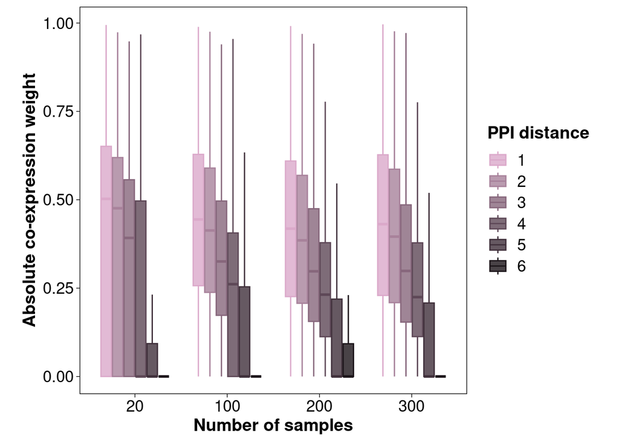

```r
boxplot_ppi_coexpression_by_distances
```

Violin plot plotting the zeroes:

```r
violinplot_ppi_coexpression_by_distances_file = sprintf("/home/j.aguirreplans/Projects/Scipher/SampleSize/data/out/plots/ppi_coexpression_violinplot_by_ppi_distance_pval_%s_%s_%s.png", as.character(threshold_selected), dataset, type_dataset)
colors_defined_filt = colors_defined[names(colors_defined) %in% c("1", "2", "3", "4", "5", "6")]
violinplot_ppi_coexpression_by_distances = coexpression_pairs_filt %>%
  select(-ppi, -nci, -distances_nci, -random_not_ppi, -random_far_not_ppi, -random_far_not_nci) %>%
  filter(!(is.na(distances_ppi))) %>%
  pivot_longer(as.character(sizes_selected), names_to = "size", values_to = "correlation", names_transform = list(size = as.character), values_transform = list(correlation = as.numeric)) %>%
  filter(!(is.na(correlation))) %>%
  #filter(abs(correlation) > 0 ) %>%
  mutate(across(c(distances_ppi), as.character)) %>%
  ggplot() +
  aes(x = reorder(size, as.numeric(size)),
      y = abs(correlation),
      fill = distances_ppi,
      colour = distances_ppi) +
  geom_violin(alpha = 0.8,
              scale = "width",
              adjust = 0.5) +
  scale_fill_manual(values = colors_defined_filt) +
  scale_color_manual(values = colors_defined_filt) +
  theme_linedraw() +
  theme(aspect.ratio=1,
        plot.title =  element_text(size = 15, face="bold"),
        axis.title = element_text(size = 14, face="bold"),
        axis.text = element_text(size = 13),
        panel.grid.major=element_blank(),
        panel.grid.minor = element_blank(),
        legend.text = element_text(size = 13),
        legend.title=element_text(size=14, face="bold"),
        text = element_text(family = "Helvetica")) +
  labs (x = "Number of samples",
        y = "Absolute co-expression weight",
        color = "PPI distance",
        fill = "PPI distance")
ggsave(
  violinplot_ppi_coexpression_by_distances_file,
  plot = violinplot_ppi_coexpression_by_distances,
  dpi = 1200,
  #width = 9300,
  #height = 6000,
  units = c("px")
)
```

```
## Saving 8400 x 6000 px image
```

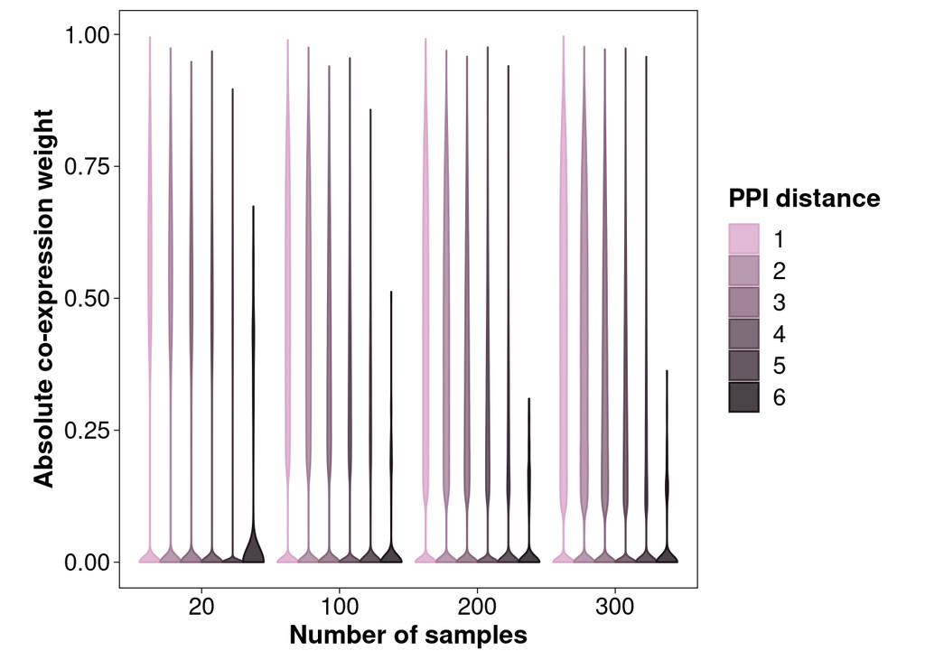

```r
violinplot_ppi_coexpression_by_distances
```

Violin plot not plotting the zeroes:

```r
violinplot_ppi_coexpression_by_distances_nozero_file = sprintf("/home/j.aguirreplans/Projects/Scipher/SampleSize/data/out/plots/ppi_coexpression_violinplot_by_ppi_distance_nozero_pval_%s_%s_%s.png", as.character(threshold_selected), dataset, type_dataset)
colors_defined_filt = colors_defined[names(colors_defined) %in% c("1", "2", "3", "4", "5", "6")]
violinplot_ppi_coexpression_by_distances_nozero = coexpression_pairs_filt %>%
  select(-ppi, -nci, -distances_nci, -random_not_ppi, -random_far_not_ppi, -random_far_not_nci) %>%
  filter(!(is.na(distances_ppi))) %>%
  pivot_longer(as.character(sizes_selected), names_to = "size", values_to = "correlation", names_transform = list(size = as.character), values_transform = list(correlation = as.numeric)) %>%
  filter(!(is.na(correlation))) %>%
  filter(abs(correlation) > 0 ) %>%
  mutate(across(c(distances_ppi), as.character)) %>%
  ggplot() +
  aes(x = reorder(size, as.numeric(size)),
      y = abs(correlation),
      fill = distances_ppi,
      colour = distances_ppi) +
  geom_violin(alpha = 0.8,
              scale = "width",
              adjust = 0.5) +
  scale_fill_manual(values = colors_defined_filt) +
  scale_color_manual(values = colors_defined_filt) +
  theme_linedraw() +
  theme(aspect.ratio=1,
        plot.title =  element_text(size = 15, face="bold"),
        axis.title = element_text(size = 14, face="bold"),
        axis.text = element_text(size = 13),
        panel.grid.major=element_blank(),
        panel.grid.minor = element_blank(),
        legend.text = element_text(size = 13),
        legend.title=element_text(size=14, face="bold"),
        text = element_text(family = "Helvetica")) +
  labs (x = "Number of samples",
        y = "Absolute co-expression weight",
        color = "PPI distance",
        fill = "PPI distance")
ggsave(
  violinplot_ppi_coexpression_by_distances_nozero_file,
  plot = violinplot_ppi_coexpression_by_distances_nozero,
  dpi = 1200,
  #width = 9300,
  #height = 6000,
  units = c("px")
)
```

```
## Saving 8400 x 6000 px image
```

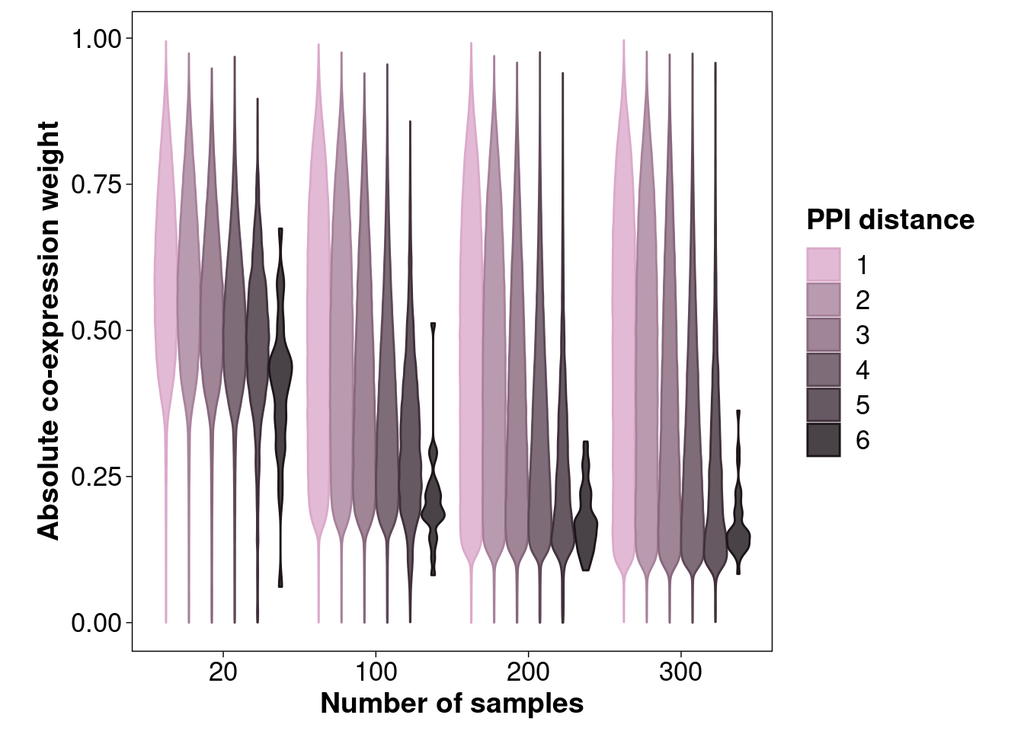

```r
violinplot_ppi_coexpression_by_distances_nozero
```

Violin plot without setting unsignificant co-expression links to 0:

```r
violinplot_ppi_coexpression_by_distances_nofilt_file = sprintf("/home/j.aguirreplans/Projects/Scipher/SampleSize/data/out/plots/ppi_coexpression_violinplot_by_ppi_distance_%s_%s.png", as.character(threshold_selected), dataset, type_dataset)
colors_defined_filt = colors_defined[names(colors_defined) %in% c("1", "2", "3", "4", "5", "6")]
violinplot_ppi_coexpression_by_distances_nofilt = coexpression_pairs %>%
  select(-ppi, -nci, -distances_nci, -random_not_ppi, -random_far_not_ppi, -random_far_not_nci) %>%
  filter(!(is.na(distances_ppi))) %>%
  pivot_longer(as.character(sizes_selected), names_to = "size", values_to = "correlation", names_transform = list(size = as.character), values_transform = list(correlation = as.numeric)) %>%
  filter(!(is.na(correlation))) %>%
  mutate(across(c(distances_ppi), as.character)) %>%
  ggplot() +
  aes(x = reorder(size, as.numeric(size)),
      y = abs(correlation),
      fill = distances_ppi,
      colour = distances_ppi) +
  geom_violin(alpha = 0.8,
              scale = "width",
              adjust = 0.5) +
  scale_fill_manual(values = colors_defined_filt) +
  scale_color_manual(values = colors_defined_filt) +
  theme_linedraw() +
  theme(aspect.ratio=1,
        plot.title =  element_text(size = 15, face="bold"),
        axis.title = element_text(size = 14, face="bold"),
        axis.text = element_text(size = 13),
        panel.grid.major=element_blank(),
        panel.grid.minor = element_blank(),
        legend.text = element_text(size = 13),
        legend.title=element_text(size=14, face="bold"),
        text = element_text(family = "Helvetica")) +
  labs (x = "Number of samples",
        y = "Absolute co-expression weight",
        color = "PPI distance",
        fill = "PPI distance")
ggsave(
  violinplot_ppi_coexpression_by_distances_nofilt_file,
  plot = violinplot_ppi_coexpression_by_distances_nofilt,
  dpi = 1200,
  #width = 9300,
  #height = 6000,
  units = c("px")
)
```

```
## Saving 8400 x 6000 px image
```

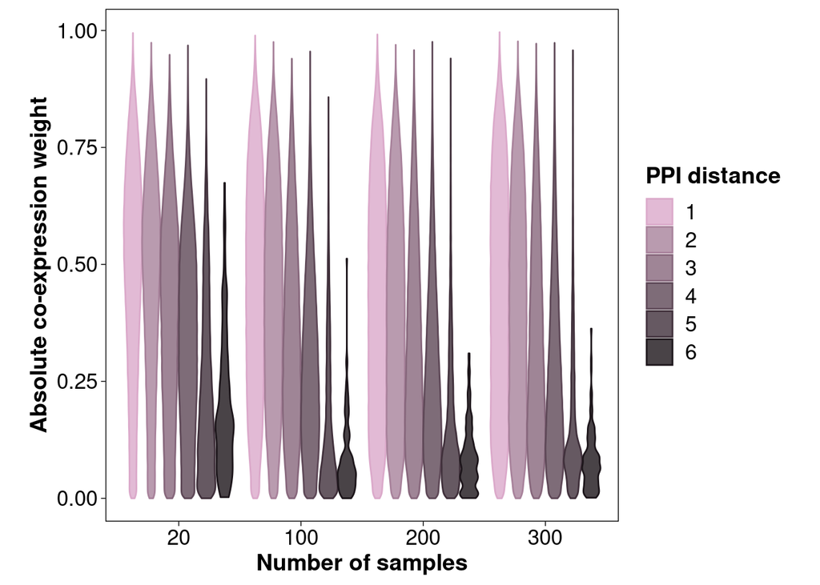

```r
violinplot_ppi_coexpression_by_distances_nofilt
```

Plot the co-expression of pairs of proteins/genes grouped by different categories:

Boxplot plotting the zeroes:

```r
boxplot_ppi_coexpression_by_types_file = sprintf("/home/j.aguirreplans/Projects/Scipher/SampleSize/data/out/plots/ppi_coexpression_boxplot_by_pair_type_pval_%s_%s_%s.png", as.character(threshold_selected), dataset, type_dataset)
#colors_defined_filt = colors_defined[names(colors_defined) %in% c("PPI", "PPI & iNCI", "Random pairs in PPI", "Random pairs in PPI (dist. > 4)", "Random pairs in PPI & iNCI (dist. > 4)")]
colors_defined_filt = colors_defined[names(colors_defined) %in% c("PPI", "Random", "Random (distance > 4)")]
boxplot_ppi_coexpression_by_types = coexpression_pairs_filt %>%
  #select(-distances_ppi, -distances_nci) %>%
  select(-distances_ppi, -distances_nci, -nci, -random_far_not_nci) %>%
  #pivot_longer(c("ppi", "nci", "random_not_ppi", "random_far_not_ppi", "random_far_not_nci"), names_to = "category", values_to = "category_bool") %>%
  pivot_longer(c("ppi", "random_not_ppi", "random_far_not_ppi"), names_to = "category", values_to = "category_bool") %>%
  filter(category_bool == TRUE) %>%
  select(-category_bool) %>%
  pivot_longer(as.character(sizes_selected), names_to = "size", values_to = "correlation", names_transform = list(size = as.character), values_transform = list(correlation = as.numeric)) %>%
  filter(!(is.na(correlation))) %>%
  #mutate(category = replace(category, category == "nci", "PPI+iNCI")) %>%
  mutate(category = replace(category, category == "ppi", "PPI")) %>%
  #mutate(category = replace(category, category == "random_not_ppi", "Random")) %>%
  mutate(category = replace(category, category == "random_far_not_ppi", "Random (distance > 4)")) %>%
  #mutate(category = replace(category, category == "random_far_not_nci", "Random pairs in PPI+iNCI (d > 4)")) %>%
  #mutate(category = factor(category, levels = c("PPI","PPI & iNCI", "Random pairs in PPI","Random pairs in PPI (dist. > 4)","Random pairs in PPI & iNCI (dist. > 4)"))) %>%
  mutate(category = factor(category, levels = c("PPI", "Random", "Random (distance > 4)"))) %>%
  ggplot() +
  aes(x = reorder(size, as.numeric(size)),
      y = abs(correlation),
      fill = category,
      colour = category) +
  geom_boxplot(alpha = 0.8,
               outlier.size = 0,
               outlier.alpha = 0) +
  scale_fill_manual(values = colors_defined_filt) +
  scale_color_manual(values = colors_defined_filt) +
  theme_linedraw() +
  theme(aspect.ratio=1,
        plot.title =  element_text(size = 15, face="bold"),
        axis.title = element_text(size = 14, face="bold"),
        axis.text = element_text(size = 13),
        panel.grid.major=element_blank(),
        panel.grid.minor = element_blank(),
        legend.text = element_text(size = 13),
        legend.title=element_text(size=14, face="bold"),
        text = element_text(family = "Helvetica")) +
  labs (x = "Number of samples",
        y = "Absolute co-expression weight",
        color = "",
        fill = "")
ggsave(
  boxplot_ppi_coexpression_by_types_file,
  plot = boxplot_ppi_coexpression_by_types,
  dpi = 1200,
  #width = 9300,
  #height = 6000,
  units = c("px")
)
```

```
## Saving 8400 x 6000 px image
```

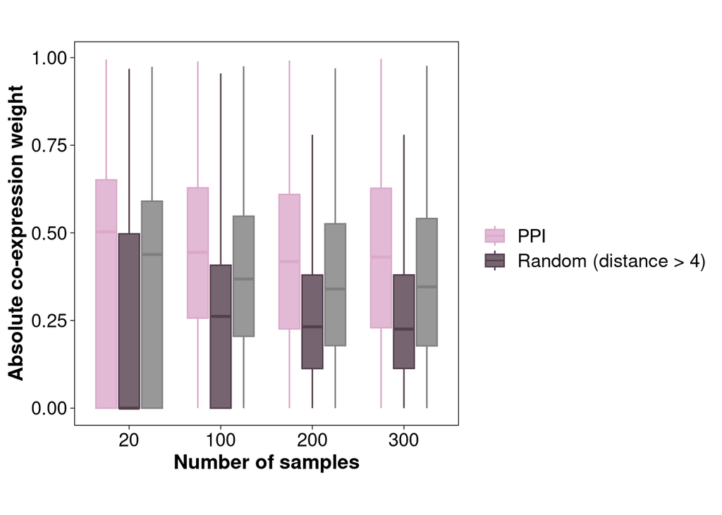

```r
boxplot_ppi_coexpression_by_types
```

Violin plot plotting the zeroes:

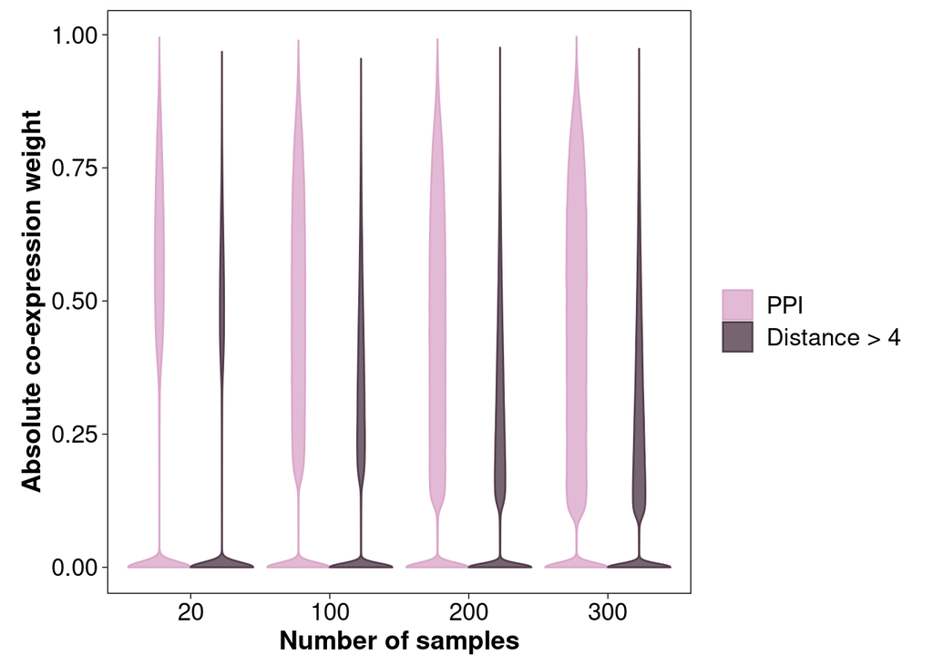

```r
violinplot_ppi_coexpression_by_types_file =  sprintf("/home/j.aguirreplans/Projects/Scipher/SampleSize/data/out/plots/ppi_coexpression_violinplot_by_pair_type_pval_%s_%s_%s.png", as.character(threshold_selected), dataset, type_dataset)
colors_defined_filt = colors_defined[names(colors_defined) %in% c("PPI", "Distance > 4")]
violinplot_ppi_coexpression_by_types = coexpression_pairs_filt %>%
  select(-distances_ppi, -distances_nci, -nci, -random_not_ppi, -random_far_not_nci) %>%
  pivot_longer(c("ppi", "random_far_not_ppi"), names_to = "category", values_to = "category_bool") %>%
  filter(category_bool == TRUE) %>%
  select(-category_bool) %>%
  pivot_longer(as.character(sizes_selected), names_to = "size", values_to = "correlation", names_transform = list(size = as.character), values_transform = list(correlation = as.numeric)) %>%
  filter(!(is.na(correlation))) %>%
  mutate(category = replace(category, category == "ppi", "PPI")) %>%
  mutate(category = replace(category, category == "random_far_not_ppi", "Distance > 4")) %>%
  mutate(category = factor(category, levels = c("PPI", "Distance > 4"))) %>%
  ggplot() +
  aes(x = reorder(size, as.numeric(size)),
      y = abs(correlation),
      fill = category,
      colour = category) +
  geom_violin(alpha = 0.8,
              scale = "width",
              adjust = 0.5) +
  scale_fill_manual(values = colors_defined_filt) +
  scale_color_manual(values = colors_defined_filt) +
  theme_linedraw() +
  theme(aspect.ratio=1,
        plot.title =  element_text(size = 15, face="bold"),
        axis.title = element_text(size = 14, face="bold"),
        axis.text = element_text(size = 13),
        panel.grid.major=element_blank(),
        panel.grid.minor = element_blank(),
        legend.text = element_text(size = 13),
        legend.title=element_text(size=14, face="bold"),
        text = element_text(family = "Helvetica")) +
  labs (x = "Number of samples",
        y = "Absolute co-expression weight",
        color = "",
        fill = ""); violinplot_ppi_coexpression_by_types
```

```r
ggsave(
  violinplot_ppi_coexpression_by_types_file,
  plot = violinplot_ppi_coexpression_by_types,
  dpi = 1200,
  #width = 9300,
  #height = 6000,
  units = c("px")
)
```

```
## Saving 8400 x 6000 px image
```

Violin plot not plotting the zeroes:

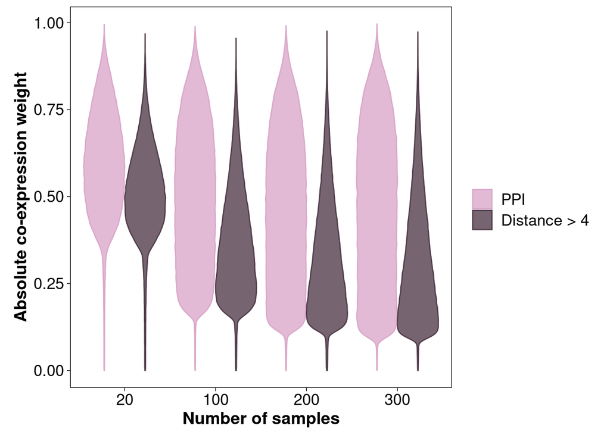

```r
violinplot_ppi_coexpression_by_types_nozero_file =  sprintf("/home/j.aguirreplans/Projects/Scipher/SampleSize/data/out/plots/ppi_coexpression_violinplot_by_pair_type_nozero_pval_%s_%s_%s.png", as.character(threshold_selected), dataset, type_dataset)
colors_defined_filt = colors_defined[names(colors_defined) %in% c("PPI", "Distance > 4")]
violinplot_ppi_coexpression_by_types_nozero = coexpression_pairs_filt %>%
  select(-distances_ppi, -distances_nci, -nci, -random_not_ppi, -random_far_not_nci) %>%
  pivot_longer(c("ppi", "random_far_not_ppi"), names_to = "category", values_to = "category_bool") %>%
  filter(category_bool == TRUE) %>%
  select(-category_bool) %>%
  pivot_longer(as.character(sizes_selected), names_to = "size", values_to = "correlation", names_transform = list(size = as.character), values_transform = list(correlation = as.numeric)) %>%
  filter(!(is.na(correlation))) %>%
  filter(abs(correlation) > 0 ) %>%
  mutate(category = replace(category, category == "ppi", "PPI")) %>%
  mutate(category = replace(category, category == "random_far_not_ppi", "Distance > 4")) %>%
  mutate(category = factor(category, levels = c("PPI", "Distance > 4"))) %>%
  ggplot() +
  aes(x = reorder(size, as.numeric(size)),
      y = abs(correlation),
      fill = category,
      colour = category) +
  geom_violin(alpha = 0.8,
              scale = "width",
              adjust = 0.5) +
  scale_fill_manual(values = colors_defined_filt) +
  scale_color_manual(values = colors_defined_filt) +
  theme_linedraw() +
  theme(aspect.ratio=1,
        plot.title =  element_text(size = 15, face="bold"),
        axis.title = element_text(size = 14, face="bold"),
        axis.text = element_text(size = 13),
        panel.grid.major=element_blank(),
        panel.grid.minor = element_blank(),
        legend.text = element_text(size = 13),
        legend.title=element_text(size=14, face="bold"),
        text = element_text(family = "Helvetica")) +
  labs (x = "Number of samples",
        y = "Absolute co-expression weight",
        color = "",
        fill = ""); violinplot_ppi_coexpression_by_types_nozero
```

```r
ggsave(
  violinplot_ppi_coexpression_by_types_nozero_file,
  plot = violinplot_ppi_coexpression_by_types_nozero,
  dpi = 1200,
  #width = 9300,
  #height = 6000,
  units = c("px")
)
```

```
## Saving 8400 x 6000 px image
```

Violin plot without setting unsignificant co-expression links to 0:

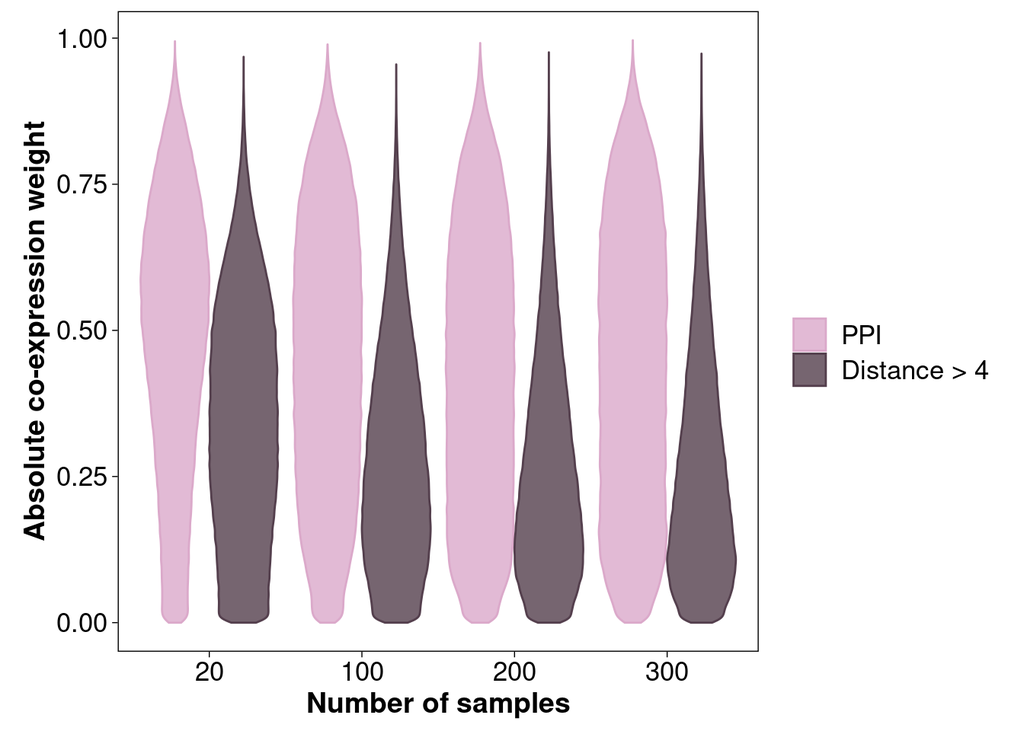

```r
violinplot_ppi_coexpression_by_types_nofilt_file =  sprintf("/home/j.aguirreplans/Projects/Scipher/SampleSize/data/out/plots/ppi_coexpression_violinplot_by_pair_type_%s_%s.png", dataset, type_dataset)
colors_defined_filt = colors_defined[names(colors_defined) %in% c("PPI", "Distance > 4")]
violinplot_ppi_coexpression_by_types_nofilt = coexpression_pairs %>%
  select(-distances_ppi, -distances_nci, -nci, -random_not_ppi, -random_far_not_nci) %>%
  pivot_longer(c("ppi", "random_far_not_ppi"), names_to = "category", values_to = "category_bool") %>%
  filter(category_bool == TRUE) %>%
  select(-category_bool) %>%
  pivot_longer(as.character(sizes_selected), names_to = "size", values_to = "correlation", names_transform = list(size = as.character), values_transform = list(correlation = as.numeric)) %>%
  filter(!(is.na(correlation))) %>%
  mutate(category = replace(category, category == "ppi", "PPI")) %>%
  mutate(category = replace(category, category == "random_far_not_ppi", "Distance > 4")) %>%
  mutate(category = factor(category, levels = c("PPI", "Distance > 4"))) %>%
  ggplot() +
  aes(x = reorder(size, as.numeric(size)),
      y = abs(correlation),
      fill = category,
      colour = category) +
  geom_violin(alpha = 0.8,
              scale = "width",
              adjust = 0.5) +
  scale_fill_manual(values = colors_defined_filt) +
  scale_color_manual(values = colors_defined_filt) +
  theme_linedraw() +
  theme(aspect.ratio=1,
        plot.title =  element_text(size = 15, face="bold"),
        axis.title = element_text(size = 14, face="bold"),
        axis.text = element_text(size = 13),
        panel.grid.major=element_blank(),
        panel.grid.minor = element_blank(),
        legend.text = element_text(size = 13),
        legend.title=element_text(size=14, face="bold"),
        text = element_text(family = "Helvetica")) +
  labs (x = "Number of samples",
        y = "Absolute co-expression weight",
        color = "",
        fill = ""); violinplot_ppi_coexpression_by_types_nofilt
```

```r
ggsave(
  violinplot_ppi_coexpression_by_types_nofilt_file,
  plot = violinplot_ppi_coexpression_by_types_nofilt,
  dpi = 1200,
  #width = 9300,
  #height = 6000,
  units = c("px")
)
```

```
## Saving 8400 x 6000 px image
```

### Calculate differences between different sample sizes of the same protein pair group

Use Friedman’s test to statistically evaluate differences between a set of protein pairs at different sample sizes. Use Dunn’s test to identify the type of difference between sample sizes if the difference exists.

#### By PPI network distance

Check differences when setting insignificant links to 0:

```r
# Select data to compare
ppi_coexpression_across_sizes_by_distances_df = coexpression_pairs_filt %>%
  select(-ppi, -nci, -distances_nci, -random_not_ppi, -random_far_not_ppi, -random_far_not_nci) %>%
  filter(!(is.na(distances_ppi))) %>%
  pivot_longer(as.character(sizes_selected), names_to = "size", values_to = "correlation", names_transform = list(size = as.numeric), values_transform = list(correlation = as.numeric)) %>%
  filter(!(is.na(correlation))) %>%
  unite(edge, c("Node.1", "Node.2"), sep = "_", remove = FALSE)

friedman_results_across_sizes_by_distance_df = data.frame(matrix(ncol=length(c("distance", "friedman.statistic", "friedman.pvalue")),nrow=0, dimnames=list(NULL, c("distance", "friedman.statistic", "friedman.pvalue"))))
dunn_results_across_sizes_by_distance_df = data.frame(matrix(ncol=length(c("distance", "Comparison", "Z", "P.unadj", "P.adj")),nrow=0, dimnames=list(NULL, c("distance", "Comparison", "Z", "P.unadj", "P.adj"))))
for(distance_selected in sort(unique(ppi_coexpression_across_sizes_by_distances_df$distances_ppi))){
  # Filter co-expression by distance
  ppi_coexpression_by_selected_distance_df = ppi_coexpression_across_sizes_by_distances_df %>% filter(distances_ppi == distance_selected)
  # Run Friedman test by distance groups
  friedman_by_distances = friedman.test(y=abs(ppi_coexpression_by_selected_distance_df$correlation), groups=ppi_coexpression_by_selected_distance_df$size, blocks=ppi_coexpression_by_selected_distance_df$edge)
  # Save result
  friedman_results_across_sizes_by_distance_df = rbind(friedman_results_across_sizes_by_distance_df, data.frame(distance=distance_selected, friedman.statistic=friedman_by_distances$statistic[[1]], friedman.pvalue=friedman_by_distances$p.value))
  # Run Dunn test by distance groups
  dunn_by_distances = ppi_coexpression_by_selected_distance_df %>%
    mutate(size = factor(size, levels = sizes_selected)) %>%
    FSA::dunnTest(abs(correlation) ~ size, .)
  # Save result
  dunn_results_across_sizes_by_distance_df= rbind(dunn_results_across_sizes_by_distance_df, cbind(data.frame(distance=distance_selected), dunn_by_distances$res))
  rm(ppi_coexpression_by_selected_distance_df)
}
rm(ppi_coexpression_across_sizes_by_distances_df)

# Merge and save results
test_results_across_sizes_by_distance_df = friedman_results_across_sizes_by_distance_df %>% full_join(dunn_results_across_sizes_by_distance_df, by=c("distance")) %>% rename("comparison"="Comparison", "dunn.z"="Z", "dunn.p.unadj"="P.unadj", "dunn.p.adj"="P.adj")
test_results_by_distance_file = sprintf("/home/j.aguirreplans/Projects/Scipher/SampleSize/data/out/tables/ppi_coexpression_analysis_tests_across_sizes_by_distance_pval_%s_%s_%s.txt", as.character(threshold_selected), dataset, type_dataset)
test_results_across_sizes_by_distance_df %>% fwrite(test_results_by_distance_file)
```

The results are the following:

```r
head(test_results_across_sizes_by_distance_df)
```

```
##   distance friedman.statistic friedman.pvalue comparison     dunn.z
## 1        1           50821.24               0   100 - 20   3.290247
## 2        1           50821.24               0  100 - 200  29.903010
## 3        1           50821.24               0   20 - 200  26.612763
## 4        1           50821.24               0  100 - 300   7.500592
## 5        1           50821.24               0   20 - 300   4.210345
## 6        1           50821.24               0  200 - 300 -22.402418
##    dunn.p.unadj    dunn.p.adj
## 1  1.000994e-03  1.000994e-03
## 2 1.798222e-196 1.078933e-195
## 3 4.831237e-156 2.415618e-155
## 4  6.353019e-14  1.905906e-13
## 5  2.549810e-05  5.099621e-05
## 6 3.727849e-111 1.491139e-110
```

```r
test_results_across_sizes_by_distance_df %>% select(distance, friedman.statistic, friedman.pvalue) %>% unique() %>% arrange(distance)
```

```
##   distance friedman.statistic friedman.pvalue
## 1        1       50821.239544    0.000000e+00
## 2        2       22956.320184    0.000000e+00
## 3        3        8818.258896    0.000000e+00
## 4        4       10182.459884    0.000000e+00
## 5        5          77.805402    9.071820e-17
## 6        6           6.428571    9.252244e-02
```

```r
test_results_across_sizes_by_distance_df %>%
  select(distance, comparison, dunn.z, dunn.p.adj) %>%
  filter(comparison %in% c("100 - 20", "20 - 200", "20 - 300", "100 - 200", "100 - 300")) %>%
  unique() %>%
  arrange(distance)
```

```
##    distance comparison      dunn.z    dunn.p.adj
## 1         1   100 - 20   3.2902471  1.000994e-03
## 2         1  100 - 200  29.9030103 1.078933e-195
## 3         1   20 - 200  26.6127632 2.415618e-155
## 4         1  100 - 300   7.5005921  1.905906e-13
## 5         1   20 - 300   4.2103450  5.099621e-05
## 6         2   100 - 20   8.0713707  2.085399e-15
## 7         2  100 - 200  22.7968479 2.956466e-114
## 8         2   20 - 200  14.7254772  1.769345e-48
## 9         2  100 - 300   6.8029786  2.049557e-11
## 10        2   20 - 300  -1.2683921  2.046580e-01
## 11        3   100 - 20  26.9221510 7.254093e-159
## 12        3  100 - 200  14.0811107  1.984946e-44
## 13        3   20 - 200 -12.8410403  2.897042e-37
## 14        3  100 - 300   4.2433153  2.202417e-05
```

[output cut: 16 more lines]

Check differences when keeping all links:

```r
# Select data to compare
ppi_coexpression_across_sizes_by_distances_df = coexpression_pairs %>%
  select(-ppi, -nci, -distances_nci, -random_not_ppi, -random_far_not_ppi, -random_far_not_nci) %>%
  filter(!(is.na(distances_ppi))) %>%
  pivot_longer(as.character(sizes_selected), names_to = "size", values_to = "correlation", names_transform = list(size = as.numeric), values_transform = list(correlation = as.numeric)) %>%
  filter(!(is.na(correlation))) %>%
  unite(edge, c("Node.1", "Node.2"), sep = "_", remove = FALSE)

friedman_results_across_sizes_by_distance_df = data.frame(matrix(ncol=length(c("distance", "friedman.statistic", "friedman.pvalue")),nrow=0, dimnames=list(NULL, c("distance", "friedman.statistic", "friedman.pvalue"))))
dunn_results_across_sizes_by_distance_df = data.frame(matrix(ncol=length(c("distance", "Comparison", "Z", "P.unadj", "P.adj")),nrow=0, dimnames=list(NULL, c("distance", "Comparison", "Z", "P.unadj", "P.adj"))))
for(distance_selected in sort(unique(ppi_coexpression_across_sizes_by_distances_df$distances_ppi))){
  # Filter co-expression by distance
  ppi_coexpression_by_selected_distance_df = ppi_coexpression_across_sizes_by_distances_df %>% filter(distances_ppi == distance_selected)
  # Run Friedman test by distance groups
  friedman_by_distances = friedman.test(y=abs(ppi_coexpression_by_selected_distance_df$correlation), groups=ppi_coexpression_by_selected_distance_df$size, blocks=ppi_coexpression_by_selected_distance_df$edge)
  # Save result
  friedman_results_across_sizes_by_distance_df = rbind(friedman_results_across_sizes_by_distance_df, data.frame(distance=distance_selected, friedman.statistic=friedman_by_distances$statistic[[1]], friedman.pvalue=friedman_by_distances$p.value))
  # Run Dunn test by distance groups
  dunn_by_distances = ppi_coexpression_by_selected_distance_df %>%
    mutate(size = factor(size, levels = sizes_selected)) %>%
    FSA::dunnTest(abs(correlation) ~ size, .)
  # Save result
  dunn_results_across_sizes_by_distance_df= rbind(dunn_results_across_sizes_by_distance_df, cbind(data.frame(distance=distance_selected), dunn_by_distances$res))
  rm(ppi_coexpression_by_selected_distance_df)
}
rm(ppi_coexpression_across_sizes_by_distances_df)

# Merge and save results
test_results_across_sizes_by_distance_df = friedman_results_across_sizes_by_distance_df %>% full_join(dunn_results_across_sizes_by_distance_df, by=c("distance")) %>% rename("comparison"="Comparison", "dunn.z"="Z", "dunn.p.unadj"="P.unadj", "dunn.p.adj"="P.adj")
test_results_by_distance_file = sprintf("/home/j.aguirreplans/Projects/Scipher/SampleSize/data/out/tables/ppi_coexpression_analysis_tests_across_sizes_by_distance_%s_%s.txt", dataset, type_dataset)
test_results_across_sizes_by_distance_df %>% fwrite(test_results_by_distance_file)
```

The results are the following:

```r
head(test_results_across_sizes_by_distance_df)
```

```
##   distance friedman.statistic friedman.pvalue comparison    dunn.z
## 1        1           140804.9               0   100 - 20 -72.89625
## 2        1           140804.9               0  100 - 200  41.51558
## 3        1           140804.9               0   20 - 200 114.41183
## 4        1           140804.9               0  100 - 300  21.69269
## 5        1           140804.9               0   20 - 300  94.58894
## 6        1           140804.9               0  200 - 300 -19.82289
##    dunn.p.unadj    dunn.p.adj
## 1  0.000000e+00  0.000000e+00
## 2  0.000000e+00  0.000000e+00
## 3  0.000000e+00  0.000000e+00
## 4 2.405260e-104 4.810520e-104
## 5  0.000000e+00  0.000000e+00
## 6  1.889402e-87  1.889402e-87
```

```r
test_results_across_sizes_by_distance_df %>% select(distance, friedman.statistic, friedman.pvalue) %>% unique() %>% arrange(distance)
```

```
##   distance friedman.statistic friedman.pvalue
## 1        1        140804.9383    0.000000e+00
## 2        2         75276.2768    0.000000e+00
## 3        3         71525.3277    0.000000e+00
## 4        4        236519.1566    0.000000e+00
## 5        5          8346.7378    0.000000e+00
## 6        6           100.5375    1.191024e-21
```

```r
test_results_across_sizes_by_distance_df %>%
  select(distance, comparison, dunn.z, dunn.p.adj) %>%
  filter(comparison %in% c("100 - 20", "20 - 200", "20 - 300", "100 - 200", "100 - 300")) %>%
  unique() %>%
  arrange(distance)
```

```
##    distance comparison       dunn.z    dunn.p.adj
## 1         1   100 - 20  -72.8962542  0.000000e+00
## 2         1  100 - 200   41.5155760  0.000000e+00
## 3         1   20 - 200  114.4118302  0.000000e+00
## 4         1  100 - 300   21.6926859 4.810520e-104
## 5         1   20 - 300   94.5889401  0.000000e+00
## 6         2   100 - 20  -58.4847968  0.000000e+00
## 7         2  100 - 200   33.0693301 2.461675e-239
## 8         2   20 - 200   91.5541270  0.000000e+00
## 9         2  100 - 300   19.5315023  1.185399e-84
## 10        2   20 - 300   78.0162991  0.000000e+00
## 11        3   100 - 20  -73.8501065  0.000000e+00
## 12        3  100 - 200   31.2179487 1.824429e-213
## 13        3   20 - 200  105.0680553  0.000000e+00
## 14        3  100 - 300   26.7192721 5.621976e-157
```

[output cut: 16 more lines]

#### By protein/gene pair sets

Check differences when setting insignificant links to 0:

```r
# Select data to compare
ppi_coexpression_by_types_df = coexpression_pairs_filt %>%
  select(-distances_ppi, -distances_nci, -nci, -random_far_not_nci) %>%
  #pivot_longer(c("ppi", "random_not_ppi", "random_far_not_ppi"), names_to = "category", values_to = "category_bool") %>%
  pivot_longer(c("ppi", "random_far_not_ppi"), names_to = "category", values_to = "category_bool") %>%
  filter(category_bool == TRUE) %>%
  select(-category_bool) %>%
  pivot_longer(as.character(sizes_selected), names_to = "size", values_to = "correlation", names_transform = list(size = as.numeric), values_transform = list(correlation = as.numeric)) %>%
  filter(!(is.na(correlation))) %>%
  unite(edge, c("Node.1", "Node.2"), sep = "_", remove = FALSE)

friedman_results_by_type_df = data.frame(matrix(ncol=length(c("category", "friedman.statistic", "friedman.pvalue")),nrow=0, dimnames=list(NULL, c("category", "friedman.statistic", "friedman.pvalue"))))
dunn_results_by_type_df = data.frame(matrix(ncol=length(c("category", "Comparison", "Z", "P.unadj", "P.adj")),nrow=0, dimnames=list(NULL, c("category", "Comparison", "Z", "P.unadj", "P.adj"))))
for(category_selected in sort(unique(ppi_coexpression_by_types_df$category))){
  # Filter co-expression by type
  ppi_coexpression_by_selected_type_df = ppi_coexpression_by_types_df %>% filter(category == category_selected)
  # Run Friedman test by protein/gene pair groups
  friedman_by_type = friedman.test(y=abs(ppi_coexpression_by_selected_type_df$correlation), groups=ppi_coexpression_by_selected_type_df$size, blocks=ppi_coexpression_by_selected_type_df$edge)
  # Save result
  friedman_results_by_type_df = rbind(friedman_results_by_type_df, data.frame(category=category_selected, friedman.statistic=friedman_by_type$statistic[[1]], friedman.pvalue=friedman_by_type$p.value))
  # Run Dunn test by protein/gene pair groups
  dunn_by_type = ppi_coexpression_by_selected_type_df %>%
    mutate(size = factor(size, levels = sizes_selected)) %>%
    FSA::dunnTest(abs(correlation) ~ size, .)
  # Save result
  dunn_results_by_type_df= rbind(dunn_results_by_type_df, cbind(data.frame(category=category_selected), dunn_by_type$res))
  rm(ppi_coexpression_by_selected_type_df)
}
rm(ppi_coexpression_by_types_df)

# Merge and save results
test_results_by_type_df = friedman_results_by_type_df %>% full_join(dunn_results_by_type_df, by=c("category")) %>% rename("comparison"="Comparison", "dunn.z"="Z", "dunn.p.unadj"="P.unadj", "dunn.p.adj"="P.adj")
test_results_by_type_file = sprintf("/home/j.aguirreplans/Projects/Scipher/SampleSize/data/out/tables/ppi_coexpression_analysis_tests_across_sizes_by_pair_type_pval_%s_%s_%s.txt", as.character(threshold_selected), dataset, type_dataset)
test_results_by_type_df %>% fwrite(test_results_by_type_file)
```

The results are the following:

```r
head(test_results_by_type_df)
```

```
##   category friedman.statistic friedman.pvalue comparison     dunn.z
## 1      ppi           50821.24               0   100 - 20   3.290247
## 2      ppi           50821.24               0  100 - 200  29.903010
## 3      ppi           50821.24               0   20 - 200  26.612763
## 4      ppi           50821.24               0  100 - 300   7.500592
## 5      ppi           50821.24               0   20 - 300   4.210345
## 6      ppi           50821.24               0  200 - 300 -22.402418
##    dunn.p.unadj    dunn.p.adj
## 1  1.000994e-03  1.000994e-03
## 2 1.798222e-196 1.078933e-195
## 3 4.831237e-156 2.415618e-155
## 4  6.353019e-14  1.905906e-13
## 5  2.549810e-05  5.099621e-05
## 6 3.727849e-111 1.491139e-110
```

Check differences when keeping all links:

```r
# Select data to compare
ppi_coexpression_by_types_df = coexpression_pairs %>%
  select(-distances_ppi, -distances_nci, -nci, -random_far_not_nci) %>%
  #pivot_longer(c("ppi", "random_not_ppi", "random_far_not_ppi"), names_to = "category", values_to = "category_bool") %>%
  pivot_longer(c("ppi", "random_far_not_ppi"), names_to = "category", values_to = "category_bool") %>%
  filter(category_bool == TRUE) %>%
  select(-category_bool) %>%
  pivot_longer(as.character(sizes_selected), names_to = "size", values_to = "correlation", names_transform = list(size = as.numeric), values_transform = list(correlation = as.numeric)) %>%
  filter(!(is.na(correlation))) %>%
  unite(edge, c("Node.1", "Node.2"), sep = "_", remove = FALSE)

friedman_results_by_type_df = data.frame(matrix(ncol=length(c("category", "friedman.statistic", "friedman.pvalue")),nrow=0, dimnames=list(NULL, c("category", "friedman.statistic", "friedman.pvalue"))))
dunn_results_by_type_df = data.frame(matrix(ncol=length(c("category", "Comparison", "Z", "P.unadj", "P.adj")),nrow=0, dimnames=list(NULL, c("category", "Comparison", "Z", "P.unadj", "P.adj"))))
for(category_selected in sort(unique(ppi_coexpression_by_types_df$category))){
  # Filter co-expression by type
  ppi_coexpression_by_selected_type_df = ppi_coexpression_by_types_df %>% filter(category == category_selected)
  # Run Friedman test by protein/gene pair groups
  friedman_by_type = friedman.test(y=abs(ppi_coexpression_by_selected_type_df$correlation), groups=ppi_coexpression_by_selected_type_df$size, blocks=ppi_coexpression_by_selected_type_df$edge)
  # Save result
  friedman_results_by_type_df = rbind(friedman_results_by_type_df, data.frame(category=category_selected, friedman.statistic=friedman_by_type$statistic[[1]], friedman.pvalue=friedman_by_type$p.value))
  # Run Dunn test by protein/gene pair groups
  dunn_by_type = ppi_coexpression_by_selected_type_df %>%
    mutate(size = factor(size, levels = sizes_selected)) %>%
    FSA::dunnTest(abs(correlation) ~ size, .)
  # Save result
  dunn_results_by_type_df= rbind(dunn_results_by_type_df, cbind(data.frame(category=category_selected), dunn_by_type$res))
  rm(ppi_coexpression_by_selected_type_df)
}
rm(ppi_coexpression_by_types_df)

# Merge and save results
test_results_by_type_df = friedman_results_by_type_df %>% full_join(dunn_results_by_type_df, by=c("category")) %>% rename("comparison"="Comparison", "dunn.z"="Z", "dunn.p.unadj"="P.unadj", "dunn.p.adj"="P.adj")
test_results_by_type_file = sprintf("/home/j.aguirreplans/Projects/Scipher/SampleSize/data/out/tables/ppi_coexpression_analysis_tests_across_sizes_by_pair_type_%s_%s.txt", dataset, type_dataset)
test_results_by_type_df %>% fwrite(test_results_by_type_file)
```

### Calculate differences between groups of protein/gene pairs of the same sample size

#### By PPI network distance

Check differences when setting insignificant links to 0:

```r
# Select data to compare
ppi_coexpression_across_distances_by_sizes_df = coexpression_pairs_filt %>%
  select(-ppi, -nci, -distances_nci, -random_not_ppi, -random_far_not_ppi, -random_far_not_nci) %>%
  filter(!(is.na(distances_ppi))) %>%
  pivot_longer(as.character(sizes_selected), names_to = "size", values_to = "correlation", names_transform = list(size = as.numeric), values_transform = list(correlation = as.numeric)) %>%
  filter(!(is.na(correlation))) %>%
  unite(edge, c("Node.1", "Node.2"), sep = "_", remove = FALSE)

kw_results_across_distances_by_sizes_df = data.frame(matrix(ncol=length(c("size", "kw.statistic", "kw.pvalue")),nrow=0, dimnames=list(NULL, c("size", "kw.statistic", "kw.pvalue"))))
dunn_results_across_distances_by_sizes_df = data.frame(matrix(ncol=length(c("size", "Comparison", "Z", "P.unadj", "P.adj")),nrow=0, dimnames=list(NULL, c("size", "Comparison", "Z", "P.unadj", "P.adj"))))
for(size_selected in sort(unique(ppi_coexpression_across_distances_by_sizes_df$size))){
  # Filter co-expression by size
  ppi_coexpression_by_selected_size_df = ppi_coexpression_across_distances_by_sizes_df %>% filter(size == size_selected)
  # Run KW test across distance groups
  kw_across_distances = ppi_coexpression_by_selected_size_df %>%
    mutate(distances_ppi = factor(distances_ppi, levels = c(1,2,3,4,5,6))) %>%
    kruskal.test(abs(correlation) ~ distances_ppi, .)
  # Save result
  kw_results_across_distances_by_sizes_df = rbind(kw_results_across_distances_by_sizes_df, data.frame(size=size_selected, kw.statistic=kw_across_distances$statistic[[1]], kw.pvalue=kw_across_distances$p.value))
  # Run Dunn test across distance groups
  dunn_across_distances = ppi_coexpression_by_selected_size_df %>%
    mutate(distances_ppi = factor(distances_ppi, levels = c(1,2,3,4,5,6))) %>%
    FSA::dunnTest(abs(correlation) ~ distances_ppi, .)
  # Save result
  dunn_results_across_distances_by_sizes_df= rbind(dunn_results_across_distances_by_sizes_df, cbind(data.frame(size=size_selected), dunn_across_distances$res))
  rm(ppi_coexpression_by_selected_size_df)
}
rm(ppi_coexpression_across_distances_by_sizes_df)

# Merge and save results
test_results_across_distances_by_sizes_df = kw_results_across_distances_by_sizes_df %>% full_join(dunn_results_across_distances_by_sizes_df, by=c("size")) %>% rename("comparison"="Comparison", "dunn.z"="Z", "dunn.p.unadj"="P.unadj", "dunn.p.adj"="P.adj")
test_results_across_distances_by_sizes_file = sprintf("/home/j.aguirreplans/Projects/Scipher/SampleSize/data/out/tables/ppi_coexpression_analysis_statistic_tests_across_distance_by_sizes_pval_%s_%s_%s.txt", as.character(threshold_selected), dataset, type_dataset)
test_results_across_distances_by_sizes_df %>% fwrite(test_results_across_distances_by_sizes_file)
```

The results are the following:

```r
head(test_results_across_distances_by_sizes_df)
```

```
##   size kw.statistic kw.pvalue comparison    dunn.z dunn.p.unadj dunn.p.adj
## 1   20     99238.72         0      1 - 2  41.88681            0          0
## 2   20     99238.72         0      1 - 3 136.86560            0          0
## 3   20     99238.72         0      2 - 3  85.69767            0          0
## 4   20     99238.72         0      1 - 4 283.95615            0          0
## 5   20     99238.72         0      2 - 4 191.43519            0          0
## 6   20     99238.72         0      3 - 4  83.45573            0          0
```

Here we find that the absolute co-expression weights from protein pairs that are close in the protein-protein network interactome are, on median, higher.

```r
test_results_across_distances_by_sizes_df %>% select(size, kw.statistic, kw.pvalue) %>% unique() %>% arrange(size)
```

```
##   size kw.statistic kw.pvalue
## 1   20     99238.72         0
## 2  100    135588.43         0
## 3  200    132451.68         0
## 4  300    147560.55         0
```

```r
test_results_across_distances_by_sizes_df %>%
  select(size, comparison, dunn.z, dunn.p.adj) %>%
  filter(comparison %in% c("1 - 6", "1 - 4", "1 - 2")) %>%
  unique() %>%
  arrange(comparison, size)
```

```
##    size comparison    dunn.z    dunn.p.adj
## 1    20      1 - 2  41.88681  0.000000e+00
## 2   100      1 - 2  39.87183  0.000000e+00
## 3   200      1 - 2  40.22212  0.000000e+00
## 4   300      1 - 2  40.18413  0.000000e+00
## 5    20      1 - 4 283.95615  0.000000e+00
## 6   100      1 - 4 324.74894  0.000000e+00
## 7   200      1 - 4 320.09042  0.000000e+00
## 8   300      1 - 4 337.41995  0.000000e+00
## 9    20      1 - 6  14.31957  8.256540e-46
## 10  100      1 - 6  20.22273  3.088410e-90
## 11  200      1 - 6  20.26863  1.216733e-90
## 12  300      1 - 6  21.44852 2.356861e-101
```

Check differences when keeping all links:

```r
# Select data to compare
ppi_coexpression_across_distances_by_sizes_df = coexpression_pairs %>%
  select(-ppi, -nci, -distances_nci, -random_not_ppi, -random_far_not_ppi, -random_far_not_nci) %>%
  filter(!(is.na(distances_ppi))) %>%
  pivot_longer(as.character(sizes_selected), names_to = "size", values_to = "correlation", names_transform = list(size = as.numeric), values_transform = list(correlation = as.numeric)) %>%
  filter(!(is.na(correlation))) %>%
  unite(edge, c("Node.1", "Node.2"), sep = "_", remove = FALSE)

kw_results_across_distances_by_sizes_df = data.frame(matrix(ncol=length(c("size", "kw.statistic", "kw.pvalue")),nrow=0, dimnames=list(NULL, c("size", "kw.statistic", "kw.pvalue"))))
dunn_results_across_distances_by_sizes_df = data.frame(matrix(ncol=length(c("size", "Comparison", "Z", "P.unadj", "P.adj")),nrow=0, dimnames=list(NULL, c("size", "Comparison", "Z", "P.unadj", "P.adj"))))
for(size_selected in sort(unique(ppi_coexpression_across_distances_by_sizes_df$size))){
  # Filter co-expression by size
  ppi_coexpression_by_selected_size_df = ppi_coexpression_across_distances_by_sizes_df %>% filter(size == size_selected)
  # Run KW test across distance groups
  kw_across_distances = ppi_coexpression_by_selected_size_df %>%
    mutate(distances_ppi = factor(distances_ppi, levels = c(1,2,3,4,5,6))) %>%
    kruskal.test(abs(correlation) ~ distances_ppi, .)
  # Save result
  kw_results_across_distances_by_sizes_df = rbind(kw_results_across_distances_by_sizes_df, data.frame(size=size_selected, kw.statistic=kw_across_distances$statistic[[1]], kw.pvalue=kw_across_distances$p.value))
  # Run Dunn test across distance groups
  dunn_across_distances = ppi_coexpression_by_selected_size_df %>%
    mutate(distances_ppi = factor(distances_ppi, levels = c(1,2,3,4,5,6))) %>%
    FSA::dunnTest(abs(correlation) ~ distances_ppi, .)
  # Save result
  dunn_results_across_distances_by_sizes_df= rbind(dunn_results_across_distances_by_sizes_df, cbind(data.frame(size=size_selected), dunn_across_distances$res))
  rm(ppi_coexpression_by_selected_size_df)
}
rm(ppi_coexpression_across_distances_by_sizes_df)

# Merge and save results
test_results_across_distances_by_sizes_df = kw_results_across_distances_by_sizes_df %>% full_join(dunn_results_across_distances_by_sizes_df, by=c("size")) %>% rename("comparison"="Comparison", "dunn.z"="Z", "dunn.p.unadj"="P.unadj", "dunn.p.adj"="P.adj")
test_results_across_distances_by_sizes_file = sprintf("/home/j.aguirreplans/Projects/Scipher/SampleSize/data/out/tables/ppi_coexpression_analysis_statistic_tests_across_distance_by_sizes_%s_%s.txt", dataset, type_dataset)
test_results_across_distances_by_sizes_df %>% fwrite(test_results_across_distances_by_sizes_file)
```

The results are the following:

```r
test_results_across_distances_by_sizes_df %>% select(size, kw.statistic, kw.pvalue) %>% unique() %>% arrange(size)
```

```
##   size kw.statistic kw.pvalue
## 1   20     99405.75         0
## 2  100    137969.19         0
## 3  200    132681.41         0
## 4  300    146389.82         0
```

```r
test_results_across_distances_by_sizes_df %>%
  select(size, comparison, dunn.z, dunn.p.adj) %>%
  filter(comparison %in% c("1 - 6", "1 - 4", "1 - 2")) %>%
  unique() %>%
  arrange(comparison, size)
```

```
##    size comparison    dunn.z    dunn.p.adj
## 1    20      1 - 2  40.28670  0.000000e+00
## 2   100      1 - 2  39.54816  0.000000e+00
## 3   200      1 - 2  39.97873  0.000000e+00
## 4   300      1 - 2  40.13642  0.000000e+00
## 5    20      1 - 4 278.58018  0.000000e+00
## 6   100      1 - 4 324.35084  0.000000e+00
## 7   200      1 - 4 319.90778  0.000000e+00
## 8   300      1 - 4 337.46479  0.000000e+00
## 9    20      1 - 6  16.43128  5.710972e-60
## 10  100      1 - 6  21.70562 9.078155e-104
## 11  200      1 - 6  20.66272  3.750484e-94
## 12  300      1 - 6  21.21902  3.187089e-99
```

#### By protein/gene pair sets

Check differences when setting insignificant links to 0:

```r
# Select data to compare
ppi_coexpression_across_types_by_sizes_df = coexpression_pairs_filt %>%
  select(-distances_ppi, -distances_nci, -nci, -random_far_not_nci) %>%
  #pivot_longer(c("ppi", "random_not_ppi", "random_far_not_ppi"), names_to = "category", values_to = "category_bool") %>%
  pivot_longer(c("ppi", "random_far_not_ppi"), names_to = "category", values_to = "category_bool") %>%
  filter(category_bool == TRUE) %>%
  select(-category_bool) %>%
  pivot_longer(as.character(sizes_selected), names_to = "size", values_to = "correlation", names_transform = list(size = as.numeric), values_transform = list(correlation = as.numeric)) %>%
  filter(!(is.na(correlation))) %>%
  unite(edge, c("Node.1", "Node.2"), sep = "_", remove = FALSE)

kw_results_across_types_by_sizes_df = data.frame(matrix(ncol=length(c("size", "kw.statistic", "kw.pvalue")),nrow=0, dimnames=list(NULL, c("size", "kw.statistic", "kw.pvalue"))))
wilcox_results_across_types_by_sizes_df = data.frame(matrix(ncol=length(c("size", "w.statistic", "w.pvalue")),nrow=0, dimnames=list(NULL, c("size", "w.statistic", "w.pvalue"))))
for(size_selected in sort(unique(ppi_coexpression_across_types_by_sizes_df$size))){
  # Filter co-expression by size
  ppi_coexpression_by_selected_size_df = ppi_coexpression_across_types_by_sizes_df %>%
    filter(size == size_selected) %>%
    mutate(category = factor(category, levels = c("ppi", "random_far_not_ppi")))
  # Run KW test across types
  kw_across_types = ppi_coexpression_by_selected_size_df %>%
    kruskal.test(abs(correlation) ~ category, .)
  # Save result
  kw_results_across_types_by_sizes_df = rbind(kw_results_across_types_by_sizes_df, data.frame(size=size_selected, kw.statistic=kw_across_types$statistic[[1]], kw.pvalue=kw_across_types$p.value))
  # # Run Dunn test across types
  # dunn_across_types = ppi_coexpression_by_selected_size_df %>%
  #   mutate(category = factor(category, levels = c("ppi", "random_far_not_ppi"))) %>%
  #   FSA::dunnTest(abs(correlation) ~ category, .) # ERROR: Error in Psort[1, i] : incorrect number of dimensions
  # Run Wilcoxon test instead of Dunn, because there are only two groups
  wilcox_across_types = wilcox.test(abs((ppi_coexpression_by_selected_size_df %>% filter(category == "ppi"))$correlation), abs((ppi_coexpression_by_selected_size_df %>% filter(category == "random_far_not_ppi"))$correlation), alternative = "greater", correct = FALSE, exact = FALSE)
  # Save result
  wilcox_results_across_types_by_sizes_df= rbind(wilcox_results_across_types_by_sizes_df, data.frame(size=size_selected, w.statistic=as.numeric(wilcox_across_types$statistic), w.pvalue=wilcox_across_types$p.value))
  rm(ppi_coexpression_by_selected_size_df)
}
rm(ppi_coexpression_across_types_by_sizes_df)

# Merge and save results
test_results_across_types_by_sizes_df = kw_results_across_types_by_sizes_df %>% full_join(wilcox_results_across_types_by_sizes_df, by=c("size"))
test_results_across_types_by_sizes_file = sprintf("/home/j.aguirreplans/Projects/Scipher/SampleSize/data/out/tables/ppi_coexpression_analysis_statistic_tests_across_pair_type_by_sizes_pval_%s_%s_%s.txt", as.character(threshold_selected), dataset, type_dataset)
test_results_across_types_by_sizes_df %>% fwrite(test_results_across_types_by_sizes_file)
```

The results are the following:

```r
test_results_across_types_by_sizes_df
```

```
##   size kw.statistic kw.pvalue  w.statistic w.pvalue
## 1   20     75233.39         0 112822459032        0
## 2  100     97873.90         0 117951355923        0
## 3  200     95194.00         0 117582211582        0
## 4  300    105212.27         0 119316814198        0
```

Check differences when keeping all links:

```r
# Select data to compare
ppi_coexpression_across_types_by_sizes_df = coexpression_pairs %>%
  select(-distances_ppi, -distances_nci, -nci, -random_far_not_nci) %>%
  #pivot_longer(c("ppi", "random_not_ppi", "random_far_not_ppi"), names_to = "category", values_to = "category_bool") %>%
  pivot_longer(c("ppi", "random_far_not_ppi"), names_to = "category", values_to = "category_bool") %>%
  filter(category_bool == TRUE) %>%
  select(-category_bool) %>%
  pivot_longer(as.character(sizes_selected), names_to = "size", values_to = "correlation", names_transform = list(size = as.numeric), values_transform = list(correlation = as.numeric)) %>%
  filter(!(is.na(correlation))) %>%
  unite(edge, c("Node.1", "Node.2"), sep = "_", remove = FALSE)

kw_results_across_types_by_sizes_df = data.frame(matrix(ncol=length(c("size", "kw.statistic", "kw.pvalue")),nrow=0, dimnames=list(NULL, c("size", "kw.statistic", "kw.pvalue"))))
wilcox_results_across_types_by_sizes_df = data.frame(matrix(ncol=length(c("size", "w.statistic", "w.pvalue")),nrow=0, dimnames=list(NULL, c("size", "w.statistic", "w.pvalue"))))
for(size_selected in sort(unique(ppi_coexpression_across_types_by_sizes_df$size))){
  # Filter co-expression by size
  ppi_coexpression_by_selected_size_df = ppi_coexpression_across_types_by_sizes_df %>%
    filter(size == size_selected) %>%
    mutate(category = factor(category, levels = c("ppi", "random_far_not_ppi")))
  # Run KW test across types
  kw_across_types = ppi_coexpression_by_selected_size_df %>%
    kruskal.test(abs(correlation) ~ category, .)
  # Save result
  kw_results_across_types_by_sizes_df = rbind(kw_results_across_types_by_sizes_df, data.frame(size=size_selected, kw.statistic=kw_across_types$statistic[[1]], kw.pvalue=kw_across_types$p.value))
  # # Run Dunn test across types
  # dunn_across_types = ppi_coexpression_by_selected_size_df %>%
  #   mutate(category = factor(category, levels = c("ppi", "random_far_not_ppi"))) %>%
  #   FSA::dunnTest(abs(correlation) ~ category, .) # ERROR: Error in Psort[1, i] : incorrect number of dimensions
  # Run Wilcoxon test instead of Dunn, because there are only two groups
  wilcox_across_types = wilcox.test(abs((ppi_coexpression_by_selected_size_df %>% filter(category == "ppi"))$correlation), abs((ppi_coexpression_by_selected_size_df %>% filter(category == "random_far_not_ppi"))$correlation), alternative = "greater", correct = FALSE, exact = FALSE)
  # Save result
  wilcox_results_across_types_by_sizes_df= rbind(wilcox_results_across_types_by_sizes_df, data.frame(size=size_selected, w.statistic=as.numeric(wilcox_across_types$statistic), w.pvalue=wilcox_across_types$p.value))
  rm(ppi_coexpression_by_selected_size_df)
}
rm(ppi_coexpression_across_types_by_sizes_df)

# Merge and save results
test_results_across_types_by_sizes_df = kw_results_across_types_by_sizes_df %>% full_join(wilcox_results_across_types_by_sizes_df, by=c("size"))
test_results_across_types_by_sizes_file = sprintf("/home/j.aguirreplans/Projects/Scipher/SampleSize/data/out/tables/ppi_coexpression_analysis_statistic_tests_across_pair_type_by_sizes_%s_%s.txt", dataset, type_dataset)
test_results_across_types_by_sizes_df %>% fwrite(test_results_across_types_by_sizes_file)
```

The results are the following:

```r
test_results_across_types_by_sizes_df
```

```
##   size kw.statistic kw.pvalue  w.statistic w.pvalue
## 1   20     72872.42         0 113513128346        0
## 2  100     97905.68         0 118133681490        0
## 3  200     95009.78         0 117632114693        0
## 4  300    105001.73         0 119332216694        0
```

### Calculate performance predicting PPIs using gene co-expression

Define functions to get performance metrics:

```r
#'  get_auc
#'  Get AUC from ROC calculation and organize it.
#'  @param rocs ROC result.
#'
get_auc = function(rocs, base = "xxx", measure = 'wto'){
  o = rocs$ci %>%
    as.vector() %>%
    t %>%
    as.data.frame()  %>%
    mutate(base = base,
           measure = measure)
  names(o)[1:3] = c("CI_l", "AUC", "CI_h")

  return(o)
}

#'  performances
#'  Calculate performances
#'  @param data Score/Value list.
#'  @param label Label list.
#'
performances = function(data, label){
  # Calculate ROC
  roc <- ROCR::performance(data,"tpr","fpr")
  roc = data.frame(x = as.numeric(roc@x.values[[1]]),
                   y = as.numeric(roc@y.values[[1]]),
                   type = "ROC")

  # Calculate AUC
  auc <- ROCR::performance(data,"auc")
  auc = auc@y.values

  # Calculate precision
  prec_rec <- ROCR::performance(data, "prec", "rec")
  prec_rec = data.frame(x = as.numeric(prec_rec@x.values[[1]]),
                        y = as.numeric(prec_rec@y.values[[1]]),
                        type = "ROCPR")

  # Calculate AUCPR
  aucpr <- ROCR::performance(data, "aucpr")
  aucpr = aucpr@y.values

  # Merge results
  out =  bind_rows(roc, prec_rec) %>%
    mutate(base = label) %>%
    mutate(AUC = auc[[1]]) %>%
    mutate(AUCPR = aucpr[[1]])

  return(out)
}
```

#### Results setting unsignificant links to 0

Calculate the AUC of predicting PPIs using gene co-expression across sample sizes:

```r
# Select correlations to analyze
ppi_vs_random_far_df = coexpression_pairs_filt %>%
  select(-distances_ppi, -distances_nci, -nci, -random_not_ppi, -random_far_not_nci) %>%
  pivot_longer(c("ppi", "random_far_not_ppi"), names_to = "category", values_to = "category_bool") %>%
  filter(category_bool == TRUE) %>%
  select(-category_bool) %>%
  pivot_longer(as.character(sizes_selected), names_to = "size", values_to = "correlation", names_transform = list(size = as.numeric), values_transform = list(correlation = as.numeric)) %>%
  filter(!(is.na(correlation))) %>%
  mutate(correlation=abs(correlation))

sum_rocs_df = data.frame(matrix(ncol=length(c("size", "CI_l", "AUC", "CI_h", "base", "measure")),nrow=0, dimnames=list(NULL, c("size", "CI_l", "AUC", "CI_h", "base", "measure"))))
perf_df = data.frame(matrix(ncol=length(c("size", "x", "y", "type", "base", "AUC", "AUCPR")),nrow=0, dimnames=list(NULL, c("size", "x", "y", "type", "base", "AUC", "AUCPR"))))
for (size_selected in sort(as.numeric(unique(ppi_vs_random_far_df$size)))){
  # Filter correlations by size
  data_filtered_by_size = ppi_vs_random_far_df %>% filter(size == size_selected)

  # Calculate ROC
  roc_result = pROC::roc(data_filtered_by_size, category, correlation, ci = T, direction="auto")

  # Get AUC from sum of ROC calculations
  sum_rocs_result = roc_result %>%
    get_auc(., base = "ppi",
            measure = "pearson")
  sum_rocs_df = rbind(sum_rocs_df, cbind(data.frame(size=size_selected), sum_rocs_result))

  # Create prediction instance
  pred_instance = ROCR::prediction(predictions = data_filtered_by_size$correlation,
                                  labels = data_filtered_by_size$category,
                                  label.ordering = c("random_far_not_ppi", "ppi")) # Negative and positive class label

  # Calculate performances
  perf_result = pred_instance  %>%
    performances(., label = "PPI")
  perf_df = rbind(perf_df, cbind(data.frame(size=size_selected), perf_result))

  #rm(data_filtered_by_size)
  #rm(pred_instance)
}
# Save results
sum_rocs_file = sprintf("/home/j.aguirreplans/Projects/Scipher/SampleSize/data/out/tables/ppi_coexpression_analysis_ppi_vs_random_far_pairs_sum_rocs_pval_%s_%s_%s.txt", as.character(threshold_selected), dataset, type_dataset)
sum_rocs_df %>% fwrite(sum_rocs_file)
perf_file = sprintf("/home/j.aguirreplans/Projects/Scipher/SampleSize/data/out/tables/ppi_coexpression_analysis_ppi_vs_random_far_pairs_performance_pval_%s_%s_%s.txt", as.character(threshold_selected), dataset, type_dataset)
perf_df %>% fwrite(perf_file)
```

Compare the results of the two ways of calculating the AUC:

```r
sum_rocs_df %>% select(size, AUC)
```

```
##   size       AUC
## 1   20 0.6678097
## 2  100 0.6981683
## 3  200 0.6959833
## 4  300 0.7062506
```

```r
perf_df %>% select("size", "AUC", "AUCPR") %>% unique()
```

```
##         size       AUC     AUCPR
## 1         20 0.6678097 0.6904976
## 944943   100 0.6981683 0.7225370
## 2229241  200 0.6959833 0.7175255
## 3593405  300 0.7062506 0.7244787
```

Plot the AUC:

```r
perf_sum = perf_df %>%
  select(size, AUC,AUCPR) %>%
  unique() %>%
  pivot_longer(cols = c("AUC", "AUCPR"))
print(perf_sum)
```

```
## # A tibble: 8 × 3
##    size name  value
##   <dbl> <chr> <dbl>
## 1    20 AUC   0.668
## 2    20 AUCPR 0.690
## 3   100 AUC   0.698
## 4   100 AUCPR 0.723
## 5   200 AUC   0.696
## 6   200 AUCPR 0.718
## 7   300 AUC   0.706
## 8   300 AUCPR 0.724
```

```r
perf_plot = perf_sum %>%
  mutate(size = factor(size,
                       levels = sizes_selected,
                       labels = sizes_selected)) %>%
  ggplot() +
  aes(x = size,
      #fill = base,
      #colour = base,
      weight = value) +
  geom_bar(col="#DBA9CA",
         fill="#DBA9CA") +
  #scale_fill_manual(values = colors_defined) +
  #scale_color_manual(values = colors_defined) +
  theme_linedraw() +
  facet_grid(vars(name))+
  theme(aspect.ratio=1,
        legend.position = "bottom",
        text = element_text(size = 18),
        axis.title  = element_text(face = "bold",
                                   hjust = 0.5),
        axis.title.x.top = element_text(face = "bold",
                                        hjust = 0.5),
        strip.text = element_text(face = "bold",
                                  hjust = 0.5)) +
  labs(y = NULL, #"AUC / AUCPR",
       x = "Number of samples"
       )
perf_plot_file =  sprintf("/home/j.aguirreplans/Projects/Scipher/SampleSize/data/out/plots/ppi_coexpression_perf_pval_%s_%s_%s.png", as.character(threshold_selected), dataset, type_dataset)
ggsave(
  perf_plot_file,
  plot = perf_plot,
  dpi = 1200,
  #width = 9300,
  #height = 6000,
  units = c("px")
)
```

```
## Saving 8400 x 6000 px image
```

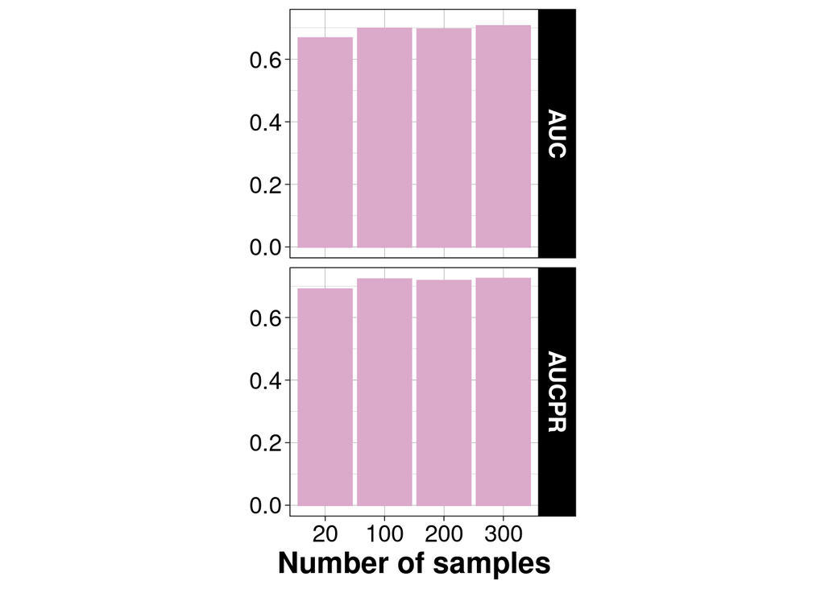

```r
 perf_plot
```

#### Results keeping the value of all the links

Calculate the AUC of predicting PPIs using gene co-expression across sample sizes:

```r
# Select correlations to analyze
ppi_vs_random_far_df = coexpression_pairs %>%
  select(-distances_ppi, -distances_nci, -nci, -random_not_ppi, -random_far_not_nci) %>%
  pivot_longer(c("ppi", "random_far_not_ppi"), names_to = "category", values_to = "category_bool") %>%
  filter(category_bool == TRUE) %>%
  select(-category_bool) %>%
  pivot_longer(as.character(sizes_selected), names_to = "size", values_to = "correlation", names_transform = list(size = as.numeric), values_transform = list(correlation = as.numeric)) %>%
  filter(!(is.na(correlation))) %>%
  mutate(correlation=abs(correlation))

sum_rocs_df = data.frame(matrix(ncol=length(c("size", "CI_l", "AUC", "CI_h", "base", "measure")),nrow=0, dimnames=list(NULL, c("size", "CI_l", "AUC", "CI_h", "base", "measure"))))
perf_df = data.frame(matrix(ncol=length(c("size", "x", "y", "type", "base", "AUC", "AUCPR")),nrow=0, dimnames=list(NULL, c("size", "x", "y", "type", "base", "AUC", "AUCPR"))))
for (size_selected in sort(as.numeric(unique(ppi_vs_random_far_df$size)))){
  # Filter correlations by size
  data_filtered_by_size = ppi_vs_random_far_df %>% filter(size == size_selected)

  # Calculate ROC
  roc_result = pROC::roc(data_filtered_by_size, category, correlation, ci = T, direction="auto")

  # Get AUC from sum of ROC calculations
  sum_rocs_result = roc_result %>%
    get_auc(., base = "ppi",
            measure = "pearson")
  sum_rocs_df = rbind(sum_rocs_df, cbind(data.frame(size=size_selected), sum_rocs_result))

  # Create prediction instance
  pred_instance = ROCR::prediction(predictions = data_filtered_by_size$correlation,
                                  labels = data_filtered_by_size$category,
                                  label.ordering = c("random_far_not_ppi", "ppi")) # Negative and positive class label

  # Calculate performances
  perf_result = pred_instance  %>%
    performances(., label = "PPI")
  perf_df = rbind(perf_df, cbind(data.frame(size=size_selected), perf_result))

  #rm(data_filtered_by_size)
  #rm(pred_instance)
}
# Save results
sum_rocs_file = sprintf("/home/j.aguirreplans/Projects/Scipher/SampleSize/data/out/tables/ppi_coexpression_analysis_ppi_vs_random_far_pairs_sum_rocs_%s_%s.txt", dataset, type_dataset)
sum_rocs_df %>% fwrite(sum_rocs_file)
perf_file = sprintf("/home/j.aguirreplans/Projects/Scipher/SampleSize/data/out/tables/ppi_coexpression_analysis_ppi_vs_random_far_pairs_performance_%s_%s.txt", dataset, type_dataset)
perf_df %>% fwrite(perf_file)
```

Compare the results of the two ways of calculating the AUC:

```r
sum_rocs_df %>% select(size, AUC)
```

```
##   size       AUC
## 1   20 0.6718979
## 2  100 0.6992475
## 3  200 0.6962787
## 4  300 0.7063418
```

```r
perf_df %>% select("size", "AUC", "AUCPR") %>% unique()
```

```
##         size       AUC     AUCPR
## 1         20 0.6718979 0.6919052
## 1644115  100 0.6992475 0.7228485
## 3288229  200 0.6962787 0.7176021
## 4932343  300 0.7063418 0.7244986
```

Plot the AUC:

```r
perf_sum = perf_df %>%
  select(size, AUC,AUCPR) %>%
  unique() %>%
  pivot_longer(cols = c("AUC", "AUCPR"))
print(perf_sum)
```

```
## # A tibble: 8 × 3
##    size name  value
##   <dbl> <chr> <dbl>
## 1    20 AUC   0.672
## 2    20 AUCPR 0.692
## 3   100 AUC   0.699
## 4   100 AUCPR 0.723
## 5   200 AUC   0.696
## 6   200 AUCPR 0.718
## 7   300 AUC   0.706
## 8   300 AUCPR 0.724
```

```r
perf_plot = perf_sum %>%
  mutate(size = factor(size,
                       levels = sizes_selected,
                       labels = sizes_selected)) %>%
  ggplot() +
  aes(x = size,
      #fill = base,
      #colour = base,
      weight = value) +
  geom_bar(col="#DBA9CA",
         fill="#DBA9CA") +
  #scale_fill_manual(values = colors_defined) +
  #scale_color_manual(values = colors_defined) +
  theme_linedraw() +
  facet_grid(vars(name))+
  theme(aspect.ratio=1,
        legend.position = "bottom",
        text = element_text(size = 18),
        axis.title  = element_text(face = "bold",
                                   hjust = 0.5),
        axis.title.x.top = element_text(face = "bold",
                                        hjust = 0.5),
        strip.text = element_text(face = "bold",
                                  hjust = 0.5)) +
  labs(y = NULL, #"AUC / AUCPR",
       x = "Number of samples"
       )
perf_plot_file =  sprintf("/home/j.aguirreplans/Projects/Scipher/SampleSize/data/out/plots/ppi_coexpression_perf_%s_%s.png", dataset, type_dataset)
ggsave(
  perf_plot_file,
  plot = perf_plot,
  dpi = 1200,
  #width = 9300,
  #height = 6000,
  units = c("px")
)
```

```
## Saving 8400 x 6000 px image
```

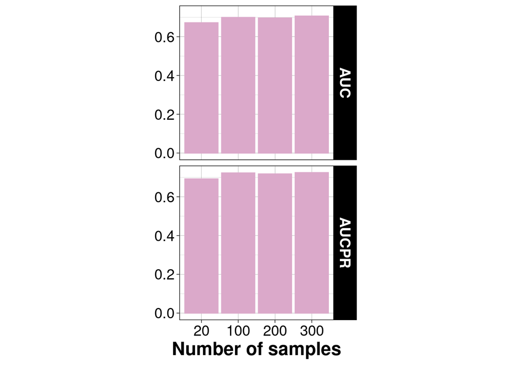

```r
 perf_plot
```